# GSEM factor analysis - sensitivity analyses

AA & JP

12 July, 2024

# Genomic SEM factor analysis: sensitivity follow-up analyses

We take the model that showed the best fit and carry it forward to do sensitivity and robustness analyses. I used the EFA-based 4-factor model, the bifactor (or S-1) per substance, and bifactor (or S-1) per trait type.

# Odd versus even chromosomes

## 4-factor model

I used the whole genome to fit both EFA and CFA models for practical and theoretical reasons. If it is true that for many traits the genetic signal is rather localized (rather than spread out evenly across the genome) this would give a different factor structure in different chromosome subsets. To check this, I compare the factor structure for even and odd chromosomes separately. Indeed, the factor structure is quite different.

EFA for even:

```r
load('data/mldsc_29May2023.14.EVEN.RData')

Ssmooth <- as.matrix((nearPD(ldscOut$S, corr = FALSE))$mat)

EFA <-factanal(covmat = Ssmooth, factors = 4, rotation = 'promax')
```

```r
print(EFA$loadings, digits = 2, cutoff = .3, sort = TRUE)
```

```
##
## Loadings:
##         Factor1 Factor2 Factor3 Factor4
## SMKCES   0.91
## PACKYE   1.10
## SMKDEP   0.73
## ALCDEP   0.62            0.43
## SMKINI   0.31    0.53
## CANEV            1.04
## CANFL            1.00
## ALCCON                   0.99
## ALCFRQ  -0.59            0.78
## ALCP                     0.75
## CANDEP                           0.59
## OPIODEP                          1.18
## SMKAGE  -0.33                   -0.43
## COCDEP   0.46                    0.32
##
##                Factor1 Factor2 Factor3 Factor4
## SS loadings       3.89    2.58    2.37    2.26
## Proportion Var    0.28    0.18    0.17    0.16
## Cumulative Var    0.28    0.46    0.63    0.79
```

EFA for odd:

```r
load('data/mldsc_29May2023.14.ODD.RData')

Ssmooth <- as.matrix((nearPD(ldscOut$S, corr = FALSE))$mat)

EFA <-factanal(covmat = Ssmooth, factors = 4, rotation = 'promax')
```

```r
print(EFA$loadings, digits = 2, cutoff = .3, sort = TRUE)
```

```
##
## Loadings:
##         Factor1 Factor2 Factor3 Factor4
## SMKINI   0.90    0.43   -0.38
## SMKCES   0.66   -0.35
## PACKYE   0.61
## SMKAGE  -0.86
## CANEV            0.96
## CANFL            0.66
## COCDEP                   0.94
## OPIODEP          0.54    0.62
## ALCCON                           0.74
## ALCFRQ  -0.35                    0.52
## ALCP                             0.58
## ALCDEP   0.38            0.44    0.54
## SMKDEP   0.49
## CANDEP   0.32    0.48    0.32
##
##                Factor1 Factor2 Factor3 Factor4
## SS loadings       3.02    2.31    1.88    1.68
## Proportion Var    0.22    0.16    0.13    0.12
## Cumulative Var    0.22    0.38    0.51    0.63
```

## Bifactor per substance model

In addition, we have a look if the best-fitting model replicates in even and odd chromosomes separately. The fit is poorer than in the total genome, again suggesting the influence of localised signals.

In even chromosomes:

```r
load("data/mldsc_29May2023.14.EVEN.RData")

bif <- 'G =~ NA*PACKYE + SMKCES + SMKDEP + SMKAGE + SMKINI + ALCCON + ALCFRQ + ALCP + ALCDEP + CANEV + CANFL + CANDEP + COCDEP + OPIODEP

ALC =~ NA*ALCCON + ALCFRQ + ALCP + ALCDEP
CAN =~ NA*CANEV + CANFL + CANDEP
DRG =~ NA*COCDEP + OPIODEP

G ~~ 0*ALC + 0*CAN + 0*DRG

G~~1*G
ALC~~1*ALC
CAN~~1*CAN
DRG~~1*DRG

a>.001
CANEV~~a*CANEV

b>.001
OPIODEP~~b*OPIODEP
'

#run the model
fit <- usermodel(ldscOut, estimation = "DWLS", model = bif, CFIcalc = TRUE)
```

```r
fitlabel <- paste0("CFI = ", round(fit$modelfit$CFI,3), ", SRMR = ", round(fit$modelfit$SRMR,3))
kable(fitlabel)
```

| x |
| --- |
| CFI = 0.86, SRMR = 0.118 |

**Click to expand table with model parameters**

```r
kable(fit$results)
```

|  | lhs | op | rhs | Unstand_Est | Unstand_SE | STD_Genotype | STD_Genotype_SE | STD_All | p_value |
| --- | --- | --- | --- | --- | --- | --- | --- | --- | --- |
| 37 | G | =~ | PACKYE | 0.1540974 | 0.00929912676839229 | 0.7070358 | 0.0426665426122334 | 0.7070358 | 0.0000000 |
| 39 | G | =~ | SMKCES | 0.1171898 | 0.00761449725666421 | 0.6062905 | 0.0393941429734608 | 0.6062905 | 0.0000000 |
| 40 | G | =~ | SMKDEP | 0.1778209 | 0.0175890005191714 | 0.7292452 | 0.0721327058760263 | 0.7292452 | 0.0000000 |
| 38 | G | =~ | SMKAGE | -0.1091559 | 0.0060173055925248 | -0.7108455 | 0.0391859171839577 | -0.7108455 | 0.0000000 |
| 41 | G | =~ | SMKINI | 0.1902947 | 0.00747435839992405 | 0.7807914 | 0.030668057124897 | 0.7807914 | 0.0000000 |
| 28 | G | =~ | ALCCON | 0.0868654 | 0.00612663091437578 | 0.4668976 | 0.0329291740964644 | 0.4668976 | 0.0000000 |
| 30 | G | =~ | ALCFRQ | -0.0403933 | 0.00645966615581908 | -0.1924106 | 0.030771835337533 | -0.1924106 | 0.0000000 |
| 31 | G | =~ | ALCP | 0.0612544 | 0.00767686672023378 | 0.3503564 | 0.0439076953385053 | 0.3503564 | 0.0000000 |
| 29 | G | =~ | ALCDEP | 0.2136303 | 0.0164116551784026 | 0.7710075 | 0.0592304866903028 | 0.7710075 | 0.0000000 |
| 33 | G | =~ | CANEV | 0.1149202 | 0.0168961850765496 | 0.2885770 | 0.0424349903317406 | 0.2860915 | 0.0000000 |
| 34 | G | =~ | CANFL | 0.0684118 | 0.014619170770757 | 0.4232600 | 0.090437245028831 | 0.4232836 | 0.0000029 |
| 32 | G | =~ | CANDEP | 0.1171558 | 0.0204120711933069 | 0.6571006 | 0.114482201398203 | 0.6571023 | 0.0000000 |
| 35 | G | =~ | COCDEP | 0.2593193 | 0.0248361885456934 | 0.7431489 | 0.0711752409048056 | 0.7431479 | 0.0000000 |
| 36 | G | =~ | OPIODEP | 0.2020593 | 0.0345307154235358 | 0.5785196 | 0.0988651668562263 | 0.5785206 | 0.0000000 |
| 4 | ALC | =~ | ALCCON | 0.1391475 | 0.00798562536832107 | 0.7478915 | 0.0429224903644269 | 0.7478915 | 0.0000000 |
| 6 | ALC | =~ | ALCFRQ | 0.1803666 | 0.0100525304183427 | 0.8592034 | 0.047883015378004 | 0.8592034 | 0.0000000 |
| 7 | ALC | =~ | ALCP | 0.1289107 | 0.00837318296078622 | 0.7373164 | 0.0478900753302938 | 0.7373164 | 0.0000000 |
| 5 | ALC | =~ | ALCDEP | 0.0929199 | 0.0221243720725734 | 0.3353561 | 0.0798480865603506 | 0.3353561 | 0.0000267 |
| 15 | CAN | =~ | CANEV | 0.3836512 | 0.0761709309357625 | 0.9660097 | 0.192334533244896 | 0.9576895 | 0.0000005 |
| 16 | CAN | =~ | CANFL | 0.1155614 | 0.0254990711196391 | 0.7139663 | 0.157960870915689 | 0.7140061 | 0.0000058 |
| 14 | CAN | =~ | CANDEP | 0.0330194 | 0.0338261538194729 | 0.1850292 | 0.189506083912553 | 0.1850297 | 0.3289904 |
| 22 | DRG | =~ | COCDEP | 0.1479575 | 0.191762648299449 | 0.4242116 | 0.549560551846974 | 0.4242111 | 0.4403717 |
| 23 | DRG | =~ | OPIODEP | 0.1233442 | 0.168568462900123 | 0.3530449 | 0.482261816548402 | 0.3530455 | 0.4643422 |
| 18 | CANEV | ~~ | CANEV | 0.0009997 | 0.0605306162481115 | 0.0009997 | 0.384724926825054 | 0.0009997 | 0.9868225 |
| 42 | OPIODEP | ~~ | OPIODEP | 0.0659464 | 0.0590844345069403 | 0.5406710 | 0.484101152700879 | 0.5406728 | 0.2643628 |
| 47 | SMKINI | ~~ | SMKINI | 0.0231872 | 0.00220025316104595 | 0.3903647 | 0.0370419403504026 | 0.3903647 | 0.0000000 |
| 45 | SMKCES | ~~ | SMKCES | 0.0236278 | 0.00219003119143482 | 0.6324118 | 0.0586177415398127 | 0.6324118 | 0.0000000 |
| 43 | PACKYE | ~~ | PACKYE | 0.0237556 | 0.00385156302397618 | 0.5001004 | 0.0810828146674689 | 0.5001004 | 0.0000000 |
| 44 | SMKAGE | ~~ | SMKAGE | 0.0116649 | 0.0015476327563405 | 0.4946986 | 0.0656331285809841 | 0.4946986 | 0.0000000 |
| 46 | SMKDEP | ~~ | SMKDEP | 0.0278391 | 0.0102456342353077 | 0.4682015 | 0.172313365711104 | 0.4682015 | 0.0065844 |
| 8 | ALCCON | ~~ | ALCCON | 0.0077077 | 0.00162277854453852 | 0.2226650 | 0.0468788353017109 | 0.2226650 | 0.0000020 |
| 10 | ALCFRQ | ~~ | ALCFRQ | 0.0099032 | 0.00284099381053881 | 0.2247476 | 0.0644642707806513 | 0.2247476 | 0.0004906 |
| 11 | ALCP | ~~ | ALCP | 0.0101985 | 0.00229057126162244 | 0.3336149 | 0.0749297048995307 | 0.3336149 | 0.0000085 |
| 9 | ALCDEP | ~~ | ALCDEP | 0.0225020 | 0.0174914606357415 | 0.2930838 | 0.227830825814812 | 0.2930837 | 0.1982838 |
| 17 | CANDEP | ~~ | CANDEP | 0.0169741 | 0.0186833451185332 | 0.5339779 | 0.587716198489643 | 0.5339806 | 0.3636053 |
| 19 | CANFL | ~~ | CANFL | 0.0080957 | 0.0110643309715733 | 0.3109917 | 0.423448017431331 | 0.3110264 | 0.4643575 |
| 20 | COCDEP | ~~ | COCDEP | 0.0326243 | 0.0643284966168393 | 0.2677769 | 0.528499296192911 | 0.2677761 | 0.6120487 |
| 2 | ALC | ~~ | CAN | 0.4078422 | 0.0908169612983611 | 0.4069819 | 0.0908707041328099 | 0.4069819 | 0.0000071 |
| 3 | ALC | ~~ | DRG | -0.0753715 | 0.188595176777607 | -0.0753788 | 0.18855616212185 | -0.0753788 | 0.6894164 |
| 13 | CAN | ~~ | DRG | 0.1759284 | 0.259115247650905 | 0.1757039 | 0.258583213970345 | 0.1757039 | 0.4971644 |
| 24 | G | ~~ | ALC | 0.0000000 |  | 0.0000000 |  | 0.0000000 | NA |
| 25 | G | ~~ | CAN | 0.0000000 |  | 0.0000000 |  | 0.0000000 | NA |
| 26 | G | ~~ | DRG | 0.0000000 |  | 0.0000000 |  | 0.0000000 | NA |
| 27 | G | ~~ | G | 1.0000000 |  | 1.0000000 |  | 1.0000000 | NA |
| 1 | ALC | ~~ | ALC | 1.0000000 |  | 1.0000000 |  | 1.0000000 | NA |
| 12 | CAN | ~~ | CAN | 1.0000000 |  | 1.0000000 |  | 1.0000000 | NA |
| 21 | DRG | ~~ | DRG | 1.0000000 |  | 1.0000000 |  | 1.0000000 | NA |

In odd chromosomes:

```r
load("data/mldsc_29May2023.14.ODD.RData")

bif <- 'G =~ NA*PACKYE + SMKCES + SMKDEP + SMKAGE + SMKINI + ALCCON + ALCFRQ + ALCP + ALCDEP + CANEV + CANFL + CANDEP + COCDEP + OPIODEP

ALC =~ NA*ALCCON + ALCFRQ + ALCP + ALCDEP
CAN =~ NA*CANEV + CANFL + CANDEP
DRG =~ NA*COCDEP + OPIODEP

G ~~ 0*ALC + 0*CAN + 0*DRG

G~~1*G
ALC~~1*ALC
CAN~~1*CAN
DRG~~1*DRG

a>.001
CANEV~~a*CANEV

b>.001
OPIODEP~~b*OPIODEP
'

#run the model
fit <- usermodel(ldscOut, estimation = "DWLS", model = bif, CFIcalc = TRUE)
```

```r
fitlabel <- paste0("CFI = ", round(fit$modelfit$CFI,3), ", SRMR = ", round(fit$modelfit$SRMR,3))
kable(fitlabel)
```

| x |
| --- |
| CFI = 0.816, SRMR = 0.108 |

**Click to expand table with model parameters**

```r
kable(fit$results)
```

|  | lhs | op | rhs | Unstand_Est | Unstand_SE | STD_Genotype | STD_Genotype_SE | STD_All | p_value |
| --- | --- | --- | --- | --- | --- | --- | --- | --- | --- |
| 37 | G | =~ | PACKYE | 0.1439313 | 0.00990611305235496 | 0.6781703 | 0.0466751031992579 | 0.6781702 | 0.0000000 |
| 39 | G | =~ | SMKCES | 0.1029508 | 0.00735584656125563 | 0.5406844 | 0.0386316575163641 | 0.5406843 | 0.0000000 |
| 40 | G | =~ | SMKDEP | 0.1528050 | 0.0148675654781927 | 0.5959051 | 0.0579801747962804 | 0.5959050 | 0.0000000 |
| 38 | G | =~ | SMKAGE | -0.1113440 | 0.00571796734850074 | -0.7261336 | 0.0372899068125526 | -0.7261336 | 0.0000000 |
| 41 | G | =~ | SMKINI | 0.1881615 | 0.00739952658541784 | 0.7692776 | 0.0302519020030177 | 0.7692777 | 0.0000000 |
| 28 | G | =~ | ALCCON | 0.0994150 | 0.00687775551976374 | 0.5188387 | 0.0358936834253032 | 0.5188387 | 0.0000000 |
| 30 | G | =~ | ALCFRQ | -0.0358648 | 0.00609214351038326 | -0.1819824 | 0.0309142021970635 | -0.1819823 | 0.0000000 |
| 31 | G | =~ | ALCP | 0.0724528 | 0.00877759739332634 | 0.4307276 | 0.0521825445319116 | 0.4307276 | 0.0000000 |
| 29 | G | =~ | ALCDEP | 0.2395311 | 0.0187522401758797 | 0.9153561 | 0.0716609418116146 | 0.9153561 | 0.0000000 |
| 33 | G | =~ | CANEV | 0.0949650 | 0.0177172064284417 | 0.2272662 | 0.0424128697941756 | 0.2262049 | 0.0000001 |
| 34 | G | =~ | CANFL | 0.0546311 | 0.0156307673663441 | 0.3765200 | 0.107707143808275 | 0.3765210 | 0.0004739 |
| 32 | G | =~ | CANDEP | 0.1641665 | 0.022516953226045 | 0.6639732 | 0.0910736174849927 | 0.6639733 | 0.0000000 |
| 35 | G | =~ | COCDEP | 0.3081377 | 0.0293769357612133 | 0.7288658 | 0.0694943884066252 | 0.7288656 | 0.0000000 |
| 36 | G | =~ | OPIODEP | 0.2369887 | 0.0400142018017858 | 0.7645511 | 0.12910254561461 | 0.7185844 | 0.0000000 |
| 4 | ALC | =~ | ALCCON | 0.1265431 | 0.00849901553920785 | 0.6603885 | 0.0443523399332706 | 0.6603885 | 0.0000000 |
| 6 | ALC | =~ | ALCFRQ | 0.1686056 | 0.00903276477328406 | 0.8555696 | 0.0458304764469378 | 0.8555695 | 0.0000000 |
| 7 | ALC | =~ | ALCP | 0.1166042 | 0.00973120113365104 | 0.6932047 | 0.0578490428744209 | 0.6932049 | 0.0000000 |
| 5 | ALC | =~ | ALCDEP | 0.0766888 | 0.020084559045101 | 0.2930638 | 0.0767519815833274 | 0.2930638 | 0.0001344 |
| 15 | CAN | =~ | CANEV | 0.4076941 | 0.0683151132232469 | 0.9781390 | 0.164051741941205 | 0.9735711 | 0.0000000 |
| 16 | CAN | =~ | CANFL | 0.1016050 | 0.0216944692976526 | 0.6998613 | 0.149584027356541 | 0.6998631 | 0.0000028 |
| 14 | CAN | =~ | CANDEP | 0.0529628 | 0.0258600401736403 | 0.2140690 | 0.104445922929149 | 0.2140690 | 0.0405545 |
| 22 | DRG | =~ | COCDEP | 0.0477294 | 0.0791673373606308 | 0.1141736 | 0.186246354156401 | 0.1141735 | 0.5465799 |
| 23 | DRG | =~ | OPIODEP | 0.2272317 | 0.340163583573565 | 0.7392500 | 1.08701209674896 | 0.6948044 | 0.5041291 |
| 18 | CANEV | ~~ | CANEV | 0.0010007 | 0.0540877469827892 | 0.0010000 | 0.311742682729731 | 0.0010000 | 0.9852385 |
| 42 | OPIODEP | ~~ | OPIODEP | 0.0010000 | 0.146900383513544 | 0.0010000 | 1.52766402506604 | 0.0008834 | 0.9945688 |
| 47 | SMKINI | ~~ | SMKINI | 0.0244223 | 0.00215543158566113 | 0.4082118 | 0.0360274795822511 | 0.4082119 | 0.0000000 |
| 45 | SMKCES | ~~ | SMKCES | 0.0256574 | 0.0026288362625961 | 0.7076608 | 0.0725070742285268 | 0.7076605 | 0.0000000 |
| 43 | PACKYE | ~~ | PACKYE | 0.0243279 | 0.00421695202546715 | 0.5400853 | 0.0936184327247859 | 0.5400852 | 0.0000000 |
| 44 | SMKAGE | ~~ | SMKAGE | 0.0111153 | 0.00133121905101298 | 0.4727301 | 0.0566167168855969 | 0.4727300 | 0.0000000 |
| 46 | SMKDEP | ~~ | SMKDEP | 0.0424051 | 0.0144343568553288 | 0.6448973 | 0.219519188517654 | 0.6448972 | 0.0033056 |
| 8 | ALCCON | ~~ | ALCCON | 0.0108196 | 0.00170791856545414 | 0.2946933 | 0.0465174537784524 | 0.2946933 | 0.0000000 |
| 10 | ALCFRQ | ~~ | ALCFRQ | 0.0091219 | 0.00259419292392301 | 0.2348832 | 0.0667869850823465 | 0.2348832 | 0.0004377 |
| 11 | ALCP | ~~ | ALCP | 0.0094494 | 0.00224145639791616 | 0.3339406 | 0.0792175323545123 | 0.3339407 | 0.0000249 |
| 9 | ALCDEP | ~~ | ALCDEP | 0.0052209 | 0.0170515495629968 | 0.0762368 | 0.249010567654463 | 0.0762368 | 0.7594641 |
| 17 | CANDEP | ~~ | CANDEP | 0.0313797 | 0.0197234048150393 | 0.5133137 | 0.322623091083882 | 0.5133139 | 0.1116123 |
| 19 | CANFL | ~~ | CANFL | 0.0077508 | 0.0112090713874085 | 0.3684218 | 0.532263231491926 | 0.3684236 | 0.4892673 |
| 20 | COCDEP | ~~ | COCDEP | 0.0814670 | 0.0372060339509695 | 0.4557194 | 0.208231777037563 | 0.4557193 | 0.0285519 |
| 2 | ALC | ~~ | CAN | 0.4567482 | 0.0844876605833987 | 0.4558668 | 0.0844459080796522 | 0.4558668 | 0.0000001 |
| 3 | ALC | ~~ | DRG | 0.2758493 | 0.442662192455791 | 0.2735231 | 0.432195500217653 | 0.2735231 | 0.5331796 |
| 13 | CAN | ~~ | DRG | 0.6810369 | 1.00968486235576 | 0.6738820 | 0.981311457619937 | 0.6738820 | 0.4999907 |
| 24 | G | ~~ | ALC | 0.0000000 |  | 0.0000000 |  | 0.0000000 | NA |
| 25 | G | ~~ | CAN | 0.0000000 |  | 0.0000000 |  | 0.0000000 | NA |
| 26 | G | ~~ | DRG | 0.0000000 |  | 0.0000000 |  | 0.0000000 | NA |
| 27 | G | ~~ | G | 1.0000000 |  | 1.0000000 |  | 1.0000000 | NA |
| 1 | ALC | ~~ | ALC | 1.0000000 |  | 1.0000000 |  | 1.0000000 | NA |
| 12 | CAN | ~~ | CAN | 1.0000000 |  | 1.0000000 |  | 1.0000000 | NA |
| 21 | DRG | ~~ | DRG | 1.0000000 |  | 1.0000000 |  | 1.0000000 | NA |

# Orthogonal 4-factor model

EFA:

```r
load('data/mldsc_29May2023.14.TOT.RData')

Ssmooth <- as.matrix((nearPD(ldscOut$S, corr = FALSE))$mat)

EFA <-factanal(covmat = Ssmooth, factors = 4, rotation = 'varimax')
```

```r
print(EFA$loadings, digits = 2, cutoff = .3, sort = TRUE)
```

```
##
## Loadings:
##         Factor1 Factor2 Factor3 Factor4
## SMKCES   0.76
## PACKYE   0.87
## SMKDEP   0.69
## ALCDEP   0.59            0.49
## SMKAGE  -0.46   -0.51
## CANDEP           0.66            0.42
## COCDEP   0.51    0.67
## OPIODEP          0.93
## ALCCON                   0.85
## ALCFRQ  -0.45            0.75
## ALCP                     0.80
## CANEV            0.30            0.81
## CANFL                            0.97
## SMKINI   0.40    0.37            0.43
##
##                Factor1 Factor2 Factor3 Factor4
## SS loadings       3.27    2.58    2.39    2.20
## Proportion Var    0.23    0.18    0.17    0.16
## Cumulative Var    0.23    0.42    0.59    0.75
```

CFA:

```r
load('data/mldsc_29May2023.14.TOT.RData')

CFA <- '
F1 =~ NA*SMKCES + PACKYE + SMKDEP + ALCDEP + SMKAGE + COCDEP + ALCFRQ + SMKINI
F2 =~ NA*SMKAGE + CANDEP + COCDEP + OPIODEP + CANEV + SMKINI
F3 =~ NA*ALCDEP + ALCCON + ALCFRQ + ALCP
F4 =~ NA*CANDEP + CANEV + CANFL + SMKINI

F1~~1*F1
F2~~1*F2
F3~~1*F3
F4~~1*F4

F1~~0*F2 + F3 + F4
F2~~0*F3 + F4
F3~~0*F4

a > .001
 SMKINI ~~ a*SMKINI

b>.001
ALCFRQ ~~ b*ALCFRQ
'

#run the model
fit <- usermodel(ldscOut, estimation = "DWLS", model = CFA, CFIcalc = TRUE)
```

```r
fitlabel <- paste0("CFI = ", round(fit$modelfit$CFI,3), ", SRMR = ", round(fit$modelfit$SRMR,3))
kable(fitlabel)
```

| x |
| --- |
| CFI = 0.941, SRMR = 0.179 |

**Click to expand table with model parameters**

```r
kable(fit$results)
```

|  | lhs | op | rhs | Unstand_Est | Unstand_SE | STD_Genotype | STD_Genotype_SE | STD_All | p_value |
| --- | --- | --- | --- | --- | --- | --- | --- | --- | --- |
| 18 | F1 | =~ | SMKCES | 0.1882288 | 0.00776244765256116 | 0.7000650 | 0.0288733780757726 | 0.7000651 | 6.83459321765316e-130 |
| 16 | F1 | =~ | PACKYE | 0.2565788 | 0.00998191925549128 | 0.8497390 | 0.0330603067678736 | 0.8497390 | 1.04490473613411e-145 |
| 19 | F1 | =~ | SMKDEP | 0.2644453 | 0.0174827347182541 | 0.7510026 | 0.049652233944559 | 0.7510026 | 1.0899394618928e-51 |
| 13 | F1 | =~ | ALCDEP | 0.2033260 | 0.0216162857494706 | 0.5342625 | 0.0567781893014877 | 0.5342626 | 5.14650081502872e-21 |
| 17 | F1 | =~ | SMKAGE | -0.1277301 | 0.00638325839291685 | -0.5837039 | 0.0291703600062034 | -0.5837039 | 4.49147047547582e-89 |
| 15 | F1 | =~ | COCDEP | 0.3474872 | 0.029824060224355 | 0.6365545 | 0.0546421782303059 | 0.6365545 | 2.26148553085466e-31 |
| 14 | F1 | =~ | ALCFRQ | -0.2525747 | 0.0147980365945893 | -0.8831545 | 0.0519496540763442 | -0.8831543 | 2.56309085466583e-65 |
| 20 | F1 | =~ | SMKINI | 0.3896891 | 0.0258644682770865 | 1.1267227 | 0.0746357626814042 | 1.1204722 | 2.68655221305129e-51 |
| 28 | F2 | =~ | SMKAGE | 0.0953869 | 0.00634401116186516 | 0.4368935 | 0.0290474529148288 | 0.4368935 | 4.28187631850123e-51 |
| 24 | F2 | =~ | CANDEP | -1.7686325 | 1.94947461349702 | -5.8164999 | 6.29180621672194 | -5.8164588 | 0.364282286280876 |
| 26 | F2 | =~ | COCDEP | -0.1859388 | 0.0311652179734323 | -0.3412931 | 0.0572116006031031 | -0.3412931 | 2.42801111791038e-09 |
| 27 | F2 | =~ | OPIODEP | -0.3664617 | 0.0379445780554026 | -0.8214485 | 0.0850627548931855 | -0.8214472 | 4.55473292719292e-22 |
| 25 | F2 | =~ | CANEV | 1.3796612 | 2.22410396397107 | 2.3678915 | 3.76522242276056 | 2.3678918 | 0.535045631731381 |
| 29 | F2 | =~ | SMKINI | 2.9407201 | 3.88931160104336 | 8.3450125 | 10.8748395391374 | 8.2987180 | 0.449587457194185 |
| 33 | F3 | =~ | ALCDEP | 0.2110712 | 0.0228776785053892 | 0.5542349 | 0.0600883871361395 | 0.5542349 | 2.80728649861497e-20 |
| 32 | F3 | =~ | ALCCON | 0.2381096 | 0.00770659601652355 | 0.9041242 | 0.0292948188043821 | 0.9041242 | 1.31655705860561e-209 |
| 34 | F3 | =~ | ALCFRQ | 0.2923746 | 0.0155811123088159 | 1.0220270 | 0.0546640139476564 | 1.0220268 | 1.4688183533417e-78 |
| 35 | F3 | =~ | ALCP | 0.1881907 | 0.00852570013704474 | 0.7814423 | 0.0354349905047582 | 0.7814424 | 5.70099014253951e-108 |
| 37 | F4 | =~ | CANDEP | -1.5717617 | 1.94745295022361 | -5.1539166 | 6.28489751494301 | -5.1538802 | 0.41961703861995 |
| 38 | F4 | =~ | CANEV | 1.8457412 | 2.22268576602056 | 3.1775895 | 3.76241953594093 | 3.1775900 | 0.406306841165967 |
| 39 | F4 | =~ | CANFL | 0.1761239 | 0.0189160948411418 | 0.8309869 | 0.0892743271152936 | 0.8309867 | 1.26876638200618e-20 |
| 40 | F4 | =~ | SMKINI | 3.1957684 | 3.8775697733539 | 9.0846428 | 10.8406579382021 | 9.0342451 | 0.40984419008502 |
| 11 | F1 | ~~ | F3 | 0.4562974 | 0.0317016574659812 | 0.4580640 | 0.0317716034824473 | 0.4580640 | 5.68552294563441e-47 |
| 12 | F1 | ~~ | F4 | -0.0636612 | 0.0776294431033295 | -0.0645088 | 0.0773637434748019 | -0.0645088 | 0.412178988288437 |
| 23 | F2 | ~~ | F4 | -0.9967578 | 0.00800363639280705 | -0.9966084 | 0.00823446143307518 | -0.9966084 | < 5e-300 |
| 46 | SMKINI | ~~ | SMKINI | 0.0009999 | 0.0115376055619709 | 0.0009994 | 0.0965679527641145 | 0.0009994 | 0.930939602241068 |
| 3 | ALCFRQ | ~~ | ALCFRQ | 0.0010007 | 0.00494561872072036 | 0.0024037 | 0.0604530373922085 | 0.0024037 | 0.839654445202501 |
| 44 | SMKCES | ~~ | SMKCES | 0.0367760 | 0.00333667221832715 | 0.5099089 | 0.0461902949247398 | 0.5099089 | 3.001767621633e-28 |
| 42 | PACKYE | ~~ | PACKYE | 0.0252108 | 0.00529258094228733 | 0.2779437 | 0.0581086312211156 | 0.2779437 | 1.90341059150648e-06 |
| 43 | SMKAGE | ~~ | SMKAGE | 0.0224145 | 0.00203860676557198 | 0.4684138 | 0.0426323666923773 | 0.4684138 | 4.03941340756144e-28 |
| 45 | SMKDEP | ~~ | SMKDEP | 0.0539316 | 0.0166586460981576 | 0.4359951 | 0.13449347161422 | 0.4359950 | 0.00120601141894353 |
| 1 | ALCCON | ~~ | ALCCON | 0.0124529 | 0.00284587252035727 | 0.1825593 | 0.0411125074857683 | 0.1825593 | 1.21008279092363e-05 |
| 4 | ALCP | ~~ | ALCP | 0.0224386 | 0.0036548379270308 | 0.3893478 | 0.0631422039689843 | 0.3893478 | 8.28255230652118e-10 |
| 2 | ALCDEP | ~~ | ALCDEP | 0.0197198 | 0.0264208244023304 | 0.1361153 | 0.18249316245462 | 0.1361153 | 0.455442911849307 |
| 6 | CANEV | ~~ | CANEV | 0.0957033 | 0.0272359895049892 | 0.2933511 | 0.0822968316568846 | 0.2933512 | 0.000441656950172625 |
| 5 | CANDEP | ~~ | CANDEP | 0.0328814 | 0.0322271165646463 | 0.3576540 | 0.359524500883289 | 0.3576490 | 0.307585379219343 |
| 7 | CANFL | ~~ | CANFL | 0.0139124 | 0.0155173032206975 | 0.3094612 | 0.345381509392966 | 0.3094610 | 0.369947473170817 |
| 8 | COCDEP | ~~ | COCDEP | 0.1422874 | 0.0504461053200696 | 0.4783175 | 0.169510669138174 | 0.4783174 | 0.00479366794423194 |
| 41 | OPIODEP | ~~ | OPIODEP | 0.0653887 | 0.0699760403563445 | 0.3252256 | 0.350490490689847 | 0.3252246 | 0.35007508032334 |
| 9 | F1 | ~~ | F1 | 1.0000000 |  | 1.0000000 |  | 1.0000000 | NA |
| 21 | F2 | ~~ | F2 | 1.0000000 |  | 1.0000000 |  | 1.0000000 | NA |
| 30 | F3 | ~~ | F3 | 1.0000000 |  | 1.0000000 |  | 1.0000000 | NA |
| 36 | F4 | ~~ | F4 | 1.0000000 |  | 1.0000000 |  | 1.0000000 | NA |
| 10 | F1 | ~~ | F2 | 0.0000000 |  | 0.0000000 |  | 0.0000000 | NA |
| 22 | F2 | ~~ | F3 | 0.0000000 |  | 0.0000000 |  | 0.0000000 | NA |
| 31 | F3 | ~~ | F4 | 0.0000000 |  | 0.0000000 |  | 0.0000000 | NA |

#### Plot

```r
semPlotModel_GSEM=function(gsem.object=GWISoutput , est.label="STD_All"){

       object=gsem.object$results
       object$free=0
       numb=1:length(which(object$op!="~~"))
       object$free[which(object$op!="~~")]=numb
       varNames <- lavaanNames(object, type = "ov")
       factNames <- lavaanNames(object, type = "lv")
       factNames <- factNames[!factNames %in% varNames]
       n <- length(varNames)
       k <- length(factNames)
       if (is.null(object$label))
         object$label <- rep("", nrow(object))
       semModel <- new("semPlotModel")
       object$est <- object[,est.label]
       object$se <- object[,"STD_Genotype_SE"]

       if (is.null(object$group))
         object$group <- ""
       semModel@Pars <- data.frame(label = object$label, lhs = ifelse(object$op ==
                                                                        "~" | object$op == "~1", object$rhs, object$lhs), edge = "--",
                                   rhs = ifelse(object$op == "~" | object$op == "~1", object$lhs,
                                                object$rhs), est = object$est, std = NA, group = object$group,
                                   fixed = object$free==0, par = object$free, stringsAsFactors = FALSE)
       semModel@Pars$edge[object$op == "~~"] <- "<->"
       semModel@Pars$edge[object$op == "~*~"] <- "<->"
       semModel@Pars$edge[object$op == "~"] <- "~>"
       semModel@Pars$edge[object$op == "=~"] <- "->"
       semModel@Pars$edge[object$op == "~1"] <- "int"
       semModel@Pars$edge[grepl("\\|", object$op)] <- "|"
       semModel@Thresholds <- semModel@Pars[grepl("\\|", semModel@Pars$edge),
                                            -(3:4)]
       semModel@Pars <- semModel@Pars[!object$op %in% c(":=", "<",
                                                        ">", "==", "|", "<", ">"), ]
       semModel@Vars <- data.frame(name = c(varNames, factNames),
                                   manifest = c(varNames, factNames) %in% varNames, exogenous = NA,
                                   stringsAsFactors = FALSE)
       semModel@ObsCovs <- list()
       semModel@ImpCovs <- list()
       semModel@Computed <- FALSE
       semModel@Original <- list(object)
       return(semModel)

}

nodelab <- c("SmkCes", "PackYea", "SmkDep", "SmkAge",
              "CocDep", "AlcDep","AlcFrq","OpioDep","SmkIni",
              "CanDep","CanIni",
              "AlcCon",  "AlcPro",
              "CanFrq",

              "F1", "F2", "F3", "F4")

edge.col <- c(rep("#bebada",8),
              rep("#fb8072",6),
              rep("#bc80bd",4),
              rep("#fdb462",4),
              rep("black", 3),
              rep("grey", 18),
              rep("white",3))


svg("results/semplot_4F_varimax.svg", width = 8, height = 8)

semPaths(semPlotModel_GSEM(fit),
         layout="tree",
         curve = 2.5,
         whatLabels = "est",
         residuals = T,
         nodeLabels = nodelab,
         edge.color = edge.col,
         color = list(lat = c("#bebada", "#fb8072", "#fdb462", "#bc80bd"),
              man = "#f2f2f2"),
         rotation = 2
         ,edge.label.position = c(rep(0.8, 8), rep(0.3, 6), rep(0.4, 4), rep(0.3, 4), rep(0.5, 30))
         )

dev.off()
```

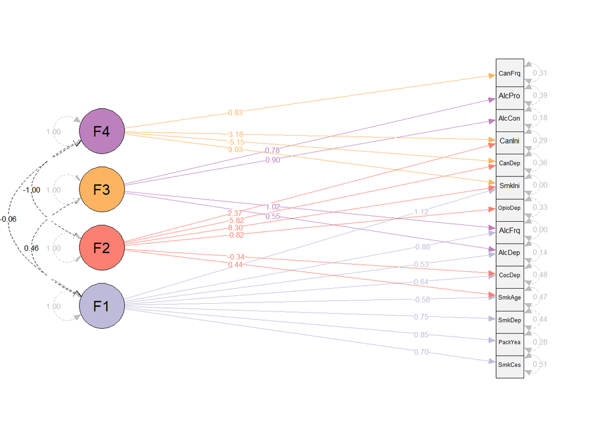

```r
semPaths(semPlotModel_GSEM(fit),
         layout="tree",
         curve = 2.5,
         whatLabels = "est",
         residuals = T,
         nodeLabels = nodelab,
         edge.color = edge.col,
         color = list(lat = c("#bebada", "#fb8072", "#fdb462", "#bc80bd"),
              man = "#f2f2f2"),
         rotation = 2
         ,edge.label.position = c(rep(0.8, 8), rep(0.3, 6), rep(0.4, 4), rep(0.3, 4), rep(0.5, 30))
         )
```

# Index-event bias adjusted

## Index event bias-adjusted - 4-factor model

```r
load('data/mldsc_29May2023.hunted.age.14.TOT.RData')

Ssmooth <- as.matrix((nearPD(ldscOut$S, corr = FALSE))$mat)

EFA <-factanal(covmat = Ssmooth, factors = 4, rotation = 'promax')
```

```r
print(EFA, digits = 2, cutoff = .3, sort = TRUE)
```

```
##
## Call:
## factanal(factors = 4, covmat = Ssmooth, rotation = "promax")
##
## Uniquenesses:
##  SMKINI  SMKCES  PACKYE  SMKAGE  SMKDEP  ALCCON  ALCFRQ    ALCP  ALCDEP   CANEV
##    0.42    0.48    0.45    0.83    0.65    0.10    0.16    0.28    0.18    0.00
##  CANDEP   CANFL  COCDEP OPIODEP
##    0.33    0.29    0.23    0.00
##
## Loadings:
##         Factor1 Factor2 Factor3 Factor4
## SMKCES   0.78
## PACKYE   0.79
## SMKDEP   0.52
## ALCDEP   0.71    0.38
## ALCCON           0.90
## ALCFRQ  -0.62    0.90
## ALCP             0.74
## CANEV                    0.98
## CANFL                    0.89
## CANDEP                           0.72
## OPIODEP                          0.98
## SMKINI   0.36            0.49
## SMKAGE                   0.31
## COCDEP   0.46                    0.49
##
##                Factor1 Factor2 Factor3 Factor4
## SS loadings       2.93    2.34    2.23    1.89
## Proportion Var    0.21    0.17    0.16    0.14
## Cumulative Var    0.21    0.38    0.54    0.67
##
## Factor Correlations:
##         Factor1 Factor2 Factor3 Factor4
## Factor1    1.00    0.40    0.54    0.23
## Factor2    0.40    1.00    0.25    0.62
## Factor3    0.54    0.25    1.00    0.24
## Factor4    0.23    0.62    0.24    1.00
##
## The degrees of freedom for the model is 41 and the fit was 28.9383
```

CFA:

```r
CFA <- '
F1 =~ NA*SMKCES + PACKYE + SMKDEP + ALCDEP + ALCFRQ + SMKINI + COCDEP
F2 =~ NA*ALCDEP + ALCCON + ALCFRQ + ALCP
F3 =~ NA*CANEV + CANFL + SMKINI + SMKAGE
F4 =~ NA*CANDEP + OPIODEP + COCDEP

F1~~1*F1
F2~~1*F2
F3~~1*F3
F4~~1*F4
'


#run the model
fit <- usermodel(ldscOut, estimation = "DWLS", model = CFA, CFIcalc = TRUE)
```

```r
fitlabel <- paste0("CFI = ", round(fit$modelfit$CFI,3), ", SRMR = ", round(fit$modelfit$SRMR,3))
kable(fitlabel)
```

| x |
| --- |
| CFI = 0.929, SRMR = 0.087 |

**Click to expand table with model parameters**

```r
kable(fit$results)
```

|  | lhs | op | rhs | Unstand_Est | Unstand_SE | STD_Genotype | STD_Genotype_SE | STD_All | p_value |
| --- | --- | --- | --- | --- | --- | --- | --- | --- | --- |
| 17 | F1 | =~ | SMKCES | 0.2056185 | 0.00858515990041156 | 0.7604520 | 0.031751031460001 | 0.7604521 | 0.0000000 |
| 16 | F1 | =~ | PACKYE | 0.2383926 | 0.0102645384425538 | 0.7867008 | 0.0338732247314413 | 0.7867009 | 0.0000000 |
| 18 | F1 | =~ | SMKDEP | 0.2258381 | 0.0186792159805341 | 0.6385964 | 0.0528186791239797 | 0.6385957 | 0.0000000 |
| 13 | F1 | =~ | ALCDEP | 0.1888593 | 0.0223528114855397 | 0.4971420 | 0.0588401841039678 | 0.4971414 | 0.0000000 |
| 14 | F1 | =~ | ALCFRQ | -0.1885201 | 0.00907769795250401 | -0.6549123 | 0.0315355852223438 | -0.6549124 | 0.0000000 |
| 19 | F1 | =~ | SMKINI | 0.1870255 | 0.00857442516687031 | 0.5417503 | 0.024837237523343 | 0.5417505 | 0.0000000 |
| 15 | F1 | =~ | COCDEP | 0.1784134 | 0.052065184134751 | 0.3269184 | 0.0954026851725417 | 0.3269185 | 0.0006109 |
| 24 | F2 | =~ | ALCDEP | 0.2498487 | 0.022657128305043 | 0.6576863 | 0.0596412677447439 | 0.6576855 | 0.0000000 |
| 23 | F2 | =~ | ALCCON | 0.2470355 | 0.00758246158979382 | 0.9402952 | 0.0288612509876964 | 0.9402956 | 0.0000000 |
| 25 | F2 | =~ | ALCFRQ | 0.2124515 | 0.0102707855574616 | 0.7380486 | 0.0356803312019823 | 0.7380487 | 0.0000000 |
| 26 | F2 | =~ | ALCP | 0.2064901 | 0.00863043351451685 | 0.8615449 | 0.0360090099525663 | 0.8615445 | 0.0000000 |
| 29 | F3 | =~ | CANEV | 0.5533675 | 0.0255432968739441 | 0.9647786 | 0.0445339313596107 | 0.9647784 | 0.0000000 |
| 30 | F3 | =~ | CANFL | 0.1557521 | 0.0187042179981737 | 0.7604395 | 0.0913209272034398 | 0.7604384 | 0.0000000 |
| 32 | F3 | =~ | SMKINI | 0.2264199 | 0.0105941301420727 | 0.6558627 | 0.0306876547649861 | 0.6558629 | 0.0000000 |
| 31 | F3 | =~ | SMKAGE | 0.0338969 | 0.00543262263512304 | 0.1578369 | 0.025296432068484 | 0.1578369 | 0.0000000 |
| 34 | F4 | =~ | CANDEP | 0.2421406 | 0.0337767730628666 | 0.8301812 | 0.115804690497427 | 0.8301798 | 0.0000000 |
| 36 | F4 | =~ | OPIODEP | 0.4054149 | 0.0611452987337034 | 0.9070148 | 0.136798297155755 | 0.9070123 | 0.0000000 |
| 35 | F4 | =~ | COCDEP | 0.3195890 | 0.061999767195049 | 0.5856014 | 0.11360637468011 | 0.5856017 | 0.0000003 |
| 42 | SMKINI | ~~ | SMKINI | 0.0465287 | 0.00370521869891182 | 0.3904062 | 0.0310892736432333 | 0.3904065 | 0.0000000 |
| 40 | SMKCES | ~~ | SMKCES | 0.0308317 | 0.00370111129479946 | 0.4217124 | 0.0506233932272668 | 0.4217126 | 0.0000000 |
| 38 | PACKYE | ~~ | PACKYE | 0.0349950 | 0.00547245800744383 | 0.3811015 | 0.0595959501243489 | 0.3811016 | 0.0000000 |
| 39 | SMKAGE | ~~ | SMKAGE | 0.0449722 | 0.00268652897676349 | 0.9750881 | 0.0582493102738686 | 0.9750875 | 0.0000000 |
| 41 | SMKDEP | ~~ | SMKDEP | 0.0740640 | 0.0169113369789583 | 0.5921968 | 0.135218431869656 | 0.5921955 | 0.0000119 |
| 1 | ALCCON | ~~ | ALCCON | 0.0079958 | 0.00257314305717307 | 0.1158441 | 0.0372798141346882 | 0.1158442 | 0.0018873 |
| 3 | ALCFRQ | ~~ | ALCFRQ | 0.0267129 | 0.00313041639823475 | 0.3223816 | 0.0377791627652322 | 0.3223817 | 0.0000000 |
| 4 | ALCP | ~~ | ALCP | 0.0148056 | 0.00352296041487063 | 0.2577412 | 0.0613288688040787 | 0.2577410 | 0.0000264 |
| 2 | ALCDEP | ~~ | ALCDEP | 0.0173273 | 0.026553487841443 | 0.1200687 | 0.183994824706811 | 0.1200684 | 0.5140503 |
| 6 | CANEV | ~~ | CANEV | 0.0227664 | 0.0242172573588606 | 0.0692027 | 0.0736127510760895 | 0.0692027 | 0.3471713 |
| 5 | CANDEP | ~~ | CANDEP | 0.0264395 | 0.0308900927143049 | 0.3108026 | 0.363107075347 | 0.3108015 | 0.3920414 |
| 7 | CANFL | ~~ | CANFL | 0.0176916 | 0.0155091006413706 | 0.4217346 | 0.369698787009746 | 0.4217334 | 0.2539851 |
| 8 | COCDEP | ~~ | COCDEP | 0.1016654 | 0.0564531631783436 | 0.3413541 | 0.189545487426666 | 0.3413545 | 0.0717218 |
| 37 | OPIODEP | ~~ | OPIODEP | 0.0354247 | 0.0799884554716316 | 0.1773295 | 0.400370412821992 | 0.1773286 | 0.6578580 |
| 10 | F1 | ~~ | F2 | 0.3061997 | 0.0340202149298416 | 0.3061998 | 0.0340202249560807 | 0.3061998 | 0.0000000 |
| 11 | F1 | ~~ | F3 | -0.1605005 | 0.0358455765940588 | -0.1605005 | 0.0358455819452807 | -0.1605005 | 0.0000076 |
| 12 | F1 | ~~ | F4 | 0.5454298 | 0.0937127799177617 | 0.5454346 | 0.0937138369801 | 0.5454346 | 0.0000000 |
| 21 | F2 | ~~ | F3 | 0.4641305 | 0.0275906324667629 | 0.4641306 | 0.0275906419163384 | 0.4641306 | 0.0000000 |
| 22 | F2 | ~~ | F4 | 0.4511476 | 0.0691541844697646 | 0.4511516 | 0.0691550552113482 | 0.4511516 | 0.0000000 |
| 28 | F3 | ~~ | F4 | 0.4786184 | 0.0714250550463928 | 0.4786220 | 0.0714260603444623 | 0.4786220 | 0.0000000 |
| 9 | F1 | ~~ | F1 | 1.0000000 |  | 1.0000000 |  | 1.0000000 | NA |
| 20 | F2 | ~~ | F2 | 1.0000000 |  | 1.0000000 |  | 1.0000000 | NA |
| 27 | F3 | ~~ | F3 | 1.0000000 |  | 1.0000000 |  | 1.0000000 | NA |
| 33 | F4 | ~~ | F4 | 1.0000000 |  | 1.0000000 |  | 1.0000000 | NA |

#### Plot

```r
nodelab <- c( "SmkCes", "SmkYea","SmkDep", "AlcDep",
               "AlcFrq", "SmkIni","AlcCon","AlcPro",
               "CocDep", "CanIni", "CanFrq","SmkAge","CanDep","OpioDep",

              "F1", "F2", "F3", "F4")

edge.col <- c(rep("#bebada",7),
              rep("#fb8072",4),
              rep("#bc80bd",4),
              rep("#fdb462",3),
              rep("grey",14),
              rep("black", 6),
              rep("grey",4))


svg("results/semplot_4F_adjusted.svg", width = 10, height = 7)

plt <- semPaths(semPlotModel_GSEM(fit),
         layout="tree",
         curve = 2.5,
         whatLabels = "est",
         residuals = T,
         nodeLabels = nodelab,
         edge.color = edge.col,
         color = list(lat = c("#bebada", "#fb8072", "#fdb462", "#bc80bd"),
              man = "#f2f2f2"),
         rotation = 2
         ,edge.label.position = c(rep(0.8, 7), rep(0.3, 4), rep(0.4, 4), rep(0.3, 3), rep(0.5, 30))
         )

dev.off()
```

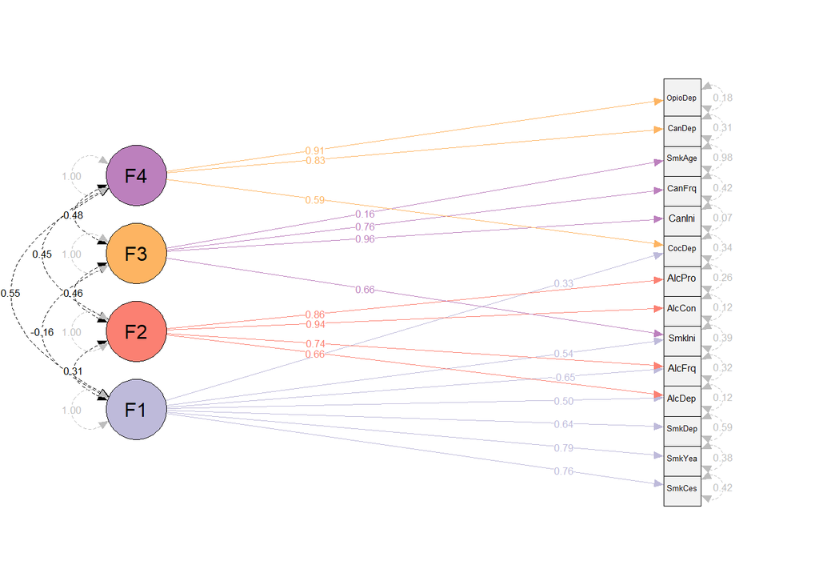

```r
plt <- semPaths(semPlotModel_GSEM(fit),
         layout="tree",
         curve = 2.5,
         whatLabels = "est",
         residuals = T,
         nodeLabels = nodelab,
         edge.color = edge.col,
         color = list(lat = c("#bebada", "#fb8072", "#fdb462", "#bc80bd"),
              man = "#f2f2f2"),
         rotation = 2
         ,edge.label.position = c(rep(0.8, 7), rep(0.3, 4), rep(0.4, 4), rep(0.3, 3), rep(0.5, 30))
         )
```

## Index event bias-adjusted - 4-factor S-1 model

```r
bif <- 'G =~ NA*SMKCES + PACKYE + SMKDEP + CANDEP + COCDEP + OPIODEP + SMKAGE + ALCDEP + CANEV + CANFL + SMKINI + ALCCON + ALCFRQ + ALCP

F2 =~ NA*ALCDEP + ALCCON + ALCFRQ + ALCP
F3 =~ NA*CANEV + CANFL + SMKINI + SMKAGE
F4 =~ NA*CANDEP + OPIODEP + COCDEP

G~~1*G
F2~~1*F2
F3~~1*F3
F4~~1*F4

G ~~ 0*F2 + 0*F3 + 0*F4
'

#run the model
fit <- usermodel(ldscOut, estimation = "DWLS", model = bif, CFIcalc = TRUE)
```

```r
fitlabel <- paste0("CFI = ", round(fit$modelfit$CFI,3), ", SRMR = ", round(fit$modelfit$SRMR,3))
kable(fitlabel)
```

| x |
| --- |
| CFI = 0.947, SRMR = 0.067 |

**Click to expand table with model parameters**

```r
kable(fit$results)
```

|  | lhs | op | rhs | Unstand_Est | Unstand_SE | STD_Genotype | STD_Genotype_SE | STD_All | p_value |
| --- | --- | --- | --- | --- | --- | --- | --- | --- | --- |
| 41 | G | =~ | SMKCES | 0.1929755 | 0.00845903179763937 | 0.7136933 | 0.0312845572077871 | 0.7136934 | 0.0000000 |
| 39 | G | =~ | PACKYE | 0.2388725 | 0.00996441279523328 | 0.7882851 | 0.0328828012712071 | 0.7882848 | 0.0000000 |
| 42 | G | =~ | SMKDEP | 0.2299694 | 0.0189795646871734 | 0.6502776 | 0.0536679556937021 | 0.6502778 | 0.0000000 |
| 34 | G | =~ | CANDEP | 0.1490351 | 0.0235488594476958 | 0.5109723 | 0.0807379360928696 | 0.5109722 | 0.0000000 |
| 37 | G | =~ | COCDEP | 0.3591401 | 0.0321162339182442 | 0.6580789 | 0.0588487563628506 | 0.6580792 | 0.0000000 |
| 38 | G | =~ | OPIODEP | 0.2192533 | 0.0388753111713636 | 0.4905281 | 0.0869744497401538 | 0.4905284 | 0.0000000 |
| 40 | G | =~ | SMKAGE | -0.0434296 | 0.00569133035530056 | -0.2022253 | 0.0265010652774365 | -0.2022252 | 0.0000000 |
| 31 | G | =~ | ALCDEP | 0.2689578 | 0.0208090402463655 | 0.7079887 | 0.0547764510781516 | 0.7079883 | 0.0000000 |
| 35 | G | =~ | CANEV | -0.0749911 | 0.0212291898802075 | -0.1307451 | 0.0370124304085161 | -0.1307451 | 0.0004117 |
| 36 | G | =~ | CANFL | 0.0189821 | 0.0154132741241822 | 0.0926786 | 0.0752532912364932 | 0.0926785 | 0.2181189 |
| 43 | G | =~ | SMKINI | 0.1540906 | 0.00783509177688854 | 0.4463493 | 0.0226956410638129 | 0.4463492 | 0.0000000 |
| 30 | G | =~ | ALCCON | 0.0837791 | 0.00902180983956293 | 0.3188898 | 0.0343398672991585 | 0.3188898 | 0.0000000 |
| 32 | G | =~ | ALCFRQ | -0.1296770 | 0.00855708946227752 | -0.4504927 | 0.0297269879174649 | -0.4504928 | 0.0000000 |
| 33 | G | =~ | ALCP | 0.0476129 | 0.00921309945782105 | 0.1986571 | 0.0384400706796339 | 0.1986571 | 0.0000002 |
| 13 | F2 | =~ | ALCDEP | 0.2379252 | 0.0221330849506927 | 0.6262993 | 0.0582618129362381 | 0.6262989 | 0.0000000 |
| 12 | F2 | =~ | ALCCON | 0.2278118 | 0.00786593583823707 | 0.8671238 | 0.0299402511607754 | 0.8671239 | 0.0000000 |
| 14 | F2 | =~ | ALCFRQ | 0.2061160 | 0.00895036319852785 | 0.7160395 | 0.0310932113792321 | 0.7160396 | 0.0000000 |
| 15 | F2 | =~ | ALCP | 0.2037740 | 0.00898082222968731 | 0.8502115 | 0.0374709456750299 | 0.8502116 | 0.0000000 |
| 18 | F3 | =~ | CANEV | 0.5380473 | 0.0251508685006637 | 0.9380699 | 0.0438497690435903 | 0.9380701 | 0.0000000 |
| 19 | F3 | =~ | CANFL | 0.1495334 | 0.018332085987352 | 0.7300786 | 0.089503986259816 | 0.7300782 | 0.0000000 |
| 21 | F3 | =~ | SMKINI | 0.2241568 | 0.0101533558390848 | 0.6493072 | 0.0294108745858352 | 0.6493072 | 0.0000000 |
| 20 | F3 | =~ | SMKAGE | 0.0399048 | 0.00526824812909695 | 0.1858123 | 0.0245310265369499 | 0.1858123 | 0.0000000 |
| 23 | F4 | =~ | CANDEP | 0.1842635 | 0.0421673199980794 | 0.6317519 | 0.14457213961934 | 0.6317518 | 0.0000124 |
| 25 | F4 | =~ | OPIODEP | 0.3516981 | 0.0755930312848958 | 0.7868414 | 0.169122151141006 | 0.7868419 | 0.0000033 |
| 24 | F4 | =~ | COCDEP | 0.2635715 | 0.0574950944306258 | 0.4829581 | 0.105352253314024 | 0.4829584 | 0.0000046 |
| 49 | SMKINI | ~~ | SMKINI | 0.0451897 | 0.00378342908840174 | 0.3791725 | 0.0317455095207817 | 0.3791725 | 0.0000000 |
| 47 | SMKCES | ~~ | SMKCES | 0.0358712 | 0.00354436882635656 | 0.4906416 | 0.0484794658449672 | 0.4906417 | 0.0000000 |
| 45 | PACKYE | ~~ | PACKYE | 0.0347659 | 0.00534739929065065 | 0.3786073 | 0.0582340612804013 | 0.3786071 | 0.0000000 |
| 46 | SMKAGE | ~~ | SMKAGE | 0.0426427 | 0.00254743998161453 | 0.9245792 | 0.0552335823947734 | 0.9245788 | 0.0000000 |
| 48 | SMKDEP | ~~ | SMKDEP | 0.0721813 | 0.0168761774014561 | 0.5771385 | 0.134937305926534 | 0.5771388 | 0.0000189 |
| 1 | ALCCON | ~~ | ALCCON | 0.0101053 | 0.00248628277904385 | 0.1464055 | 0.0360213939541345 | 0.1464055 | 0.0000481 |
| 3 | ALCFRQ | ~~ | ALCFRQ | 0.0235611 | 0.00333246782052481 | 0.2843434 | 0.0402175787966145 | 0.2843435 | 0.0000000 |
| 4 | ALCP | ~~ | ALCP | 0.0136530 | 0.00347762036294743 | 0.2376755 | 0.0605395383391652 | 0.2376755 | 0.0000864 |
| 2 | ALCDEP | ~~ | ALCDEP | 0.0153697 | 0.0264736068199118 | 0.1065024 | 0.18344131465482 | 0.1065022 | 0.5615312 |
| 6 | CANEV | ~~ | CANEV | 0.0338628 | 0.0237330736601674 | 0.1029301 | 0.0721411502015257 | 0.1029302 | 0.1536324 |
| 5 | CANDEP | ~~ | CANDEP | 0.0289074 | 0.0301633048599063 | 0.3397973 | 0.354564075340855 | 0.3397972 | 0.3378803 |
| 7 | CANFL | ~~ | CANFL | 0.0192302 | 0.0154737378604347 | 0.4583970 | 0.368855826124117 | 0.4583965 | 0.2139554 |
| 8 | COCDEP | ~~ | COCDEP | 0.0993832 | 0.056312472357704 | 0.3336827 | 0.189073164015053 | 0.3336830 | 0.0775885 |
| 44 | OPIODEP | ~~ | OPIODEP | 0.0280219 | 0.0819831520558044 | 0.1402614 | 0.410355706807758 | 0.1402616 | 0.7325011 |
| 10 | F2 | ~~ | F3 | 0.5540737 | 0.0246980946207621 | 0.5540737 | 0.0246980868807251 | 0.5540737 | 0.0000000 |
| 11 | F2 | ~~ | F4 | 0.3722265 | 0.0883945305021388 | 0.3722263 | 0.0883948418463127 | 0.3722263 | 0.0000254 |
| 17 | F3 | ~~ | F4 | 0.6784806 | 0.122257590307879 | 0.6784809 | 0.12225819653625 | 0.6784809 | 0.0000000 |
| 29 | G | ~~ | G | 1.0000000 |  | 1.0000000 |  | 1.0000000 | NA |
| 9 | F2 | ~~ | F2 | 1.0000000 |  | 1.0000000 |  | 1.0000000 | NA |
| 16 | F3 | ~~ | F3 | 1.0000000 |  | 1.0000000 |  | 1.0000000 | NA |
| 22 | F4 | ~~ | F4 | 1.0000000 |  | 1.0000000 |  | 1.0000000 | NA |
| 26 | G | ~~ | F2 | 0.0000000 |  | 0.0000000 |  | 0.0000000 | NA |
| 27 | G | ~~ | F3 | 0.0000000 |  | 0.0000000 |  | 0.0000000 | NA |
| 28 | G | ~~ | F4 | 0.0000000 |  | 0.0000000 |  | 0.0000000 | NA |

## Index event bias-adjusted - 4-factor second order model

Now we fit a hierarchical model on the 4-factor solution. Fit is OK and factor loadings make sense.

```r
bif <- 'G =~ NA*F1 + F2 + F3 + F4

F1 =~ NA*SMKCES + PACKYE + SMKDEP + ALCDEP + ALCFRQ + SMKINI + COCDEP
F2 =~ NA*ALCDEP + ALCCON + ALCFRQ + ALCP
F3 =~ NA*CANEV + CANFL + SMKINI + SMKAGE
F4 =~ NA*CANDEP + OPIODEP + COCDEP

G~~1*G
F1~~1*F1
F2~~1*F2
F3~~1*F3
F4~~1*F4

G ~~ 0*F1 + 0*F2 + 0*F3 + 0*F4
F1 ~~ 0*F2 + 0*F3 + 0*F4
F2 ~~ 0*F3 + 0*F4
F3 ~~ 0*F4

a>0.001
OPIODEP~~a*OPIODEP
'

#run the model
fit <- usermodel(ldscOut, estimation = "DWLS", model = bif, CFIcalc = TRUE)
```

```r
fitlabel <- paste0("CFI = ", round(fit$modelfit$CFI,3), ", SRMR = ", round(fit$modelfit$SRMR,3))
kable(fitlabel)
```

| x |
| --- |
| CFI = 0.908, SRMR = 0.122 |

**Click to expand table with model parameters**

```r
kable(fit$results)
```

|  | lhs | op | rhs | Unstand_Est | Unstand_SE | STD_Genotype | STD_Genotype_SE | STD_All | p_value |
| --- | --- | --- | --- | --- | --- | --- | --- | --- | --- |
| 42 | G | =~ | F1 | 0.2587718 | 0.0446557973126509 | 0.2587740 | 0.0446550984319459 | 0.2505219 | 0.0000000 |
| 43 | G | =~ | F2 | 1.5463025 | 0.318253025210325 | 1.5463660 | 0.318287445111141 | 0.8397162 | 0.0000012 |
| 44 | G | =~ | F3 | 1.0376468 | 0.127274548772029 | 1.0376231 | 0.127271414355422 | 0.7200402 | 0.0000000 |
| 45 | G | =~ | F4 | 0.8320464 | 0.176047532361874 | 0.8314249 | 0.175730824075023 | 0.6393179 | 0.0000023 |
| 17 | F1 | =~ | SMKCES | 0.1954949 | 0.00920390502451869 | 0.7230100 | 0.0340393793641164 | 0.7468257 | 0.0000000 |
| 16 | F1 | =~ | PACKYE | 0.2284705 | 0.010719340794725 | 0.7539562 | 0.0353740804737853 | 0.7787911 | 0.0000000 |
| 18 | F1 | =~ | SMKDEP | 0.2168527 | 0.0186365332340978 | 0.6131872 | 0.05269792686184 | 0.6333853 | 0.0000000 |
| 13 | F1 | =~ | ALCDEP | 0.2017921 | 0.0213811001461184 | 0.5311871 | 0.0562823272334662 | 0.5486841 | 0.0000000 |
| 14 | F1 | =~ | ALCFRQ | -0.1663474 | 0.00780664306059175 | -0.5778838 | 0.0271199816983591 | -0.5969190 | 0.0000000 |
| 19 | F1 | =~ | SMKINI | 0.1064424 | 0.00868719776332545 | 0.3083325 | 0.0251637793783074 | 0.3184889 | 0.0000000 |
| 15 | F1 | =~ | COCDEP | 0.3166776 | 0.0327899840257946 | 0.5802876 | 0.0600824817170256 | 0.5994007 | 0.0000000 |
| 24 | F2 | =~ | ALCDEP | 0.1357438 | 0.0224900924644431 | 0.3573112 | 0.0592032933710604 | 0.6580007 | 0.0000000 |
| 23 | F2 | =~ | ALCCON | 0.1318982 | 0.0203874686417006 | 0.5020319 | 0.0776054240426421 | 0.9245085 | 0.0000000 |
| 25 | F2 | =~ | ALCFRQ | 0.1076079 | 0.016724178692312 | 0.3738165 | 0.0581024059785967 | 0.6883958 | 0.0000000 |
| 26 | F2 | =~ | ALCP | 0.1115815 | 0.0170263677897066 | 0.4655411 | 0.0710434174871508 | 0.8573099 | 0.0000000 |
| 29 | F3 | =~ | CANEV | 0.3010707 | 0.0256168598746755 | 0.5249162 | 0.0446626575309191 | 0.7564370 | 0.0000000 |
| 30 | F3 | =~ | CANFL | 0.1041341 | 0.014798065658112 | 0.5084281 | 0.0722506503058272 | 0.7326767 | 0.0000000 |
| 32 | F3 | =~ | SMKINI | 0.1663010 | 0.0130194150330649 | 0.4817213 | 0.0377126575599855 | 0.6941907 | 0.0000000 |
| 31 | F3 | =~ | SMKAGE | 0.0125300 | 0.00370504298878451 | 0.0583461 | 0.0172523361399113 | 0.0840804 | 0.0007199 |
| 34 | F4 | =~ | CANDEP | 0.2001844 | 0.0412334983211907 | 0.6867153 | 0.141308639000515 | 0.8930463 | 0.0000012 |
| 36 | F4 | =~ | OPIODEP | 0.3525102 | 0.075712874401251 | 0.7894032 | 0.169374929289468 | 0.7894032 | 0.0000032 |
| 35 | F4 | =~ | COCDEP | 0.2134423 | 0.049169901107292 | 0.3913282 | 0.0900758071591791 | 0.5089163 | 0.0000142 |
| 46 | OPIODEP | ~~ | OPIODEP | 0.0010002 | 0.0877521501037014 | 0.0010000 | 0.439390759185622 | 0.0009479 | 0.9909056 |
| 51 | SMKINI | ~~ | SMKINI | 0.0401516 | 0.0042310315243795 | 0.3369004 | 0.035500955492698 | 0.3369004 | 0.0000000 |
| 49 | SMKCES | ~~ | SMKCES | 0.0323332 | 0.00381094998894395 | 0.4422513 | 0.0521257752531589 | 0.4422514 | 0.0000000 |
| 47 | PACKYE | ~~ | PACKYE | 0.0361318 | 0.00555664737601465 | 0.3934845 | 0.0605128282269348 | 0.3934844 | 0.0000000 |
| 48 | SMKAGE | ~~ | SMKAGE | 0.0457952 | 0.00269362688147561 | 0.9929304 | 0.0584031953099139 | 0.9929305 | 0.0000000 |
| 50 | SMKDEP | ~~ | SMKDEP | 0.0748928 | 0.0167946724415101 | 0.5988229 | 0.134285629798974 | 0.5988230 | 0.0000082 |
| 1 | ALCCON | ~~ | ALCCON | 0.0100278 | 0.00259268757137004 | 0.1452842 | 0.0375629720166977 | 0.1452841 | 0.0001099 |
| 3 | ALCFRQ | ~~ | ALCFRQ | 0.0283953 | 0.00328081527562291 | 0.3426857 | 0.0395943838139657 | 0.3426857 | 0.0000000 |
| 4 | ALCP | ~~ | ALCP | 0.0152237 | 0.00348331092300083 | 0.2650196 | 0.060638254261007 | 0.2650197 | 0.0000124 |
| 2 | ALCDEP | ~~ | ALCDEP | 0.0164636 | 0.0263251104653038 | 0.1140812 | 0.182412017552745 | 0.1140812 | 0.5317117 |
| 6 | CANEV | ~~ | CANEV | 0.1407412 | 0.0184240755639398 | 0.4278032 | 0.0560037647517788 | 0.4278030 | 0.0000000 |
| 5 | CANDEP | ~~ | CANDEP | 0.0172546 | 0.032894532450126 | 0.2024765 | 0.386672901626632 | 0.2024682 | 0.5999004 |
| 7 | CANFL | ~~ | CANFL | 0.0194310 | 0.0155257333176363 | 0.4631850 | 0.37009547945879 | 0.4631848 | 0.2107402 |
| 8 | COCDEP | ~~ | COCDEP | 0.0846301 | 0.0552316864075111 | 0.2840103 | 0.185451072439678 | 0.2840091 | 0.1254546 |
| 41 | G | ~~ | G | 1.0000000 |  | 1.0000000 |  | 1.0000000 | NA |
| 9 | F1 | ~~ | F1 | 1.0000000 |  | 1.0000000 |  | 0.9372388 | NA |
| 20 | F2 | ~~ | F2 | 1.0000000 |  | 1.0000000 |  | 0.2948767 | NA |
| 27 | F3 | ~~ | F3 | 1.0000000 |  | 1.0000000 |  | 0.4815421 | NA |
| 33 | F4 | ~~ | F4 | 1.0000000 |  | 1.0000000 |  | 0.5912726 | NA |
| 37 | G | ~~ | F1 | 0.0000000 |  | 0.0000000 |  | 0.0000000 | NA |
| 38 | G | ~~ | F2 | 0.0000000 |  | 0.0000000 |  | 0.0000000 | NA |
| 39 | G | ~~ | F3 | 0.0000000 |  | 0.0000000 |  | 0.0000000 | NA |
| 40 | G | ~~ | F4 | 0.0000000 |  | 0.0000000 |  | 0.0000000 | NA |
| 10 | F1 | ~~ | F2 | 0.0000000 |  | 0.0000000 |  | 0.0000000 | NA |
| 11 | F1 | ~~ | F3 | 0.0000000 |  | 0.0000000 |  | 0.0000000 | NA |
| 12 | F1 | ~~ | F4 | 0.0000000 |  | 0.0000000 |  | 0.0000000 | NA |
| 21 | F2 | ~~ | F3 | 0.0000000 |  | 0.0000000 |  | 0.0000000 | NA |
| 22 | F2 | ~~ | F4 | 0.0000000 |  | 0.0000000 |  | 0.0000000 | NA |
| 28 | F3 | ~~ | F4 | 0.0000000 |  | 0.0000000 |  | 0.0000000 | NA |

## Index event bias-adjusted - bifactor - per substance model

We now re-fit the best theoretical model (bifactor per-substance) using Hunter-slope adjusted summary statistics for smoking and cannabis traits. Interestingly, the SMK and CAN factors now have a correlation >1, and the bifactor model does not converge (restricting to 1 does not work).

```r
load('data/mldsc_29May2023.hunted.age.14.TOT.RData')

CFA <- 'G =~ NA*PACKYE + SMKCES + SMKDEP + SMKAGE + SMKINI + ALCCON + ALCFRQ + ALCP + ALCDEP + CANEV + CANFL + CANDEP + COCDEP + OPIODEP

SMK =~ NA*PACKYE + SMKCES + SMKDEP + SMKAGE + SMKINI
ALC =~ NA*ALCCON + ALCFRQ + ALCP + ALCDEP
CAN =~ NA*CANEV + CANFL + CANDEP
DRG =~ NA*COCDEP + OPIODEP

G ~~ 0*SMK + 0*ALC + 0*CAN + 0*DRG

G~~1*G
SMK~~1*SMK
ALC~~1*ALC
CAN~~1*CAN
DRG~~1*DRG

a>.001
 CANEV~~a*CANEV

b>.001
  OPIODEP ~~ b*OPIODEP

c>-0.99
  SMK~~c*CAN
'

#run the model
fit <- usermodel(ldscOut, estimation = "DWLS", model = CFA, CFIcalc = TRUE)
```

```r
fitlabel <- paste0("CFI = ", round(fit$modelfit$CFI,3), ", SRMR = ", round(fit$modelfit$SRMR,3))
kable(fitlabel)
```

| x |
| --- |
| CFI = 0.963, SRMR = 0.064 |

**Click to expand table with model parameters**

```r
kable(fit$results)
```

|  | lhs | op | rhs | Unstand_Est | Unstand_SE | STD_Genotype | STD_Genotype_SE | STD_All | p_value |
| --- | --- | --- | --- | --- | --- | --- | --- | --- | --- |
| 38 | G | =~ | PACKYE | 0.2345421 | 0.0106140290013962 | 0.7673145 | 0.0340718998478027 | 0.7673145 | 0.0000000 |
| 40 | G | =~ | SMKCES | 0.1851436 | 0.00822698768718986 | 0.6896506 | 0.0307777441472154 | 0.6896506 | 0.0000000 |
| 41 | G | =~ | SMKDEP | 0.2232539 | 0.0188355120099707 | 0.6300405 | 0.0528214047143096 | 0.6300405 | 0.0000000 |
| 39 | G | =~ | SMKAGE | -0.0320639 | 0.00645402844639879 | -0.1475903 | 0.0286050462706007 | -0.1475903 | 0.0000007 |
| 42 | G | =~ | SMKINI | 0.1979085 | 0.0115197275602695 | 0.5544676 | 0.0311671421427091 | 0.5544676 | 0.0000000 |
| 29 | G | =~ | ALCCON | 0.1183918 | 0.011610562132601 | 0.4563840 | 0.042463106690197 | 0.4563840 | 0.0000000 |
| 31 | G | =~ | ALCFRQ | -0.0945936 | 0.0127657134208106 | -0.3290240 | 0.0423800022927359 | -0.3290240 | 0.0000000 |
| 32 | G | =~ | ALCP | 0.0834916 | 0.0118910316545162 | 0.3521333 | 0.047897538018485 | 0.3521333 | 0.0000000 |
| 30 | G | =~ | ALCDEP | 0.3034389 | 0.0197505693109401 | 0.8049529 | 0.052245968964559 | 0.8049530 | 0.0000000 |
| 34 | G | =~ | CANEV | 0.0610680 | 0.0381964924404892 | 0.1106944 | 0.0643246966718103 | 0.1098395 | 0.1098680 |
| 35 | G | =~ | CANFL | 0.0556181 | 0.0190991402338987 | 0.2753101 | 0.0921561802258627 | 0.2753088 | 0.0035904 |
| 33 | G | =~ | CANDEP | 0.1807373 | 0.0234824695974698 | 0.6233784 | 0.0805917412315279 | 0.6233777 | 0.0000000 |
| 36 | G | =~ | COCDEP | 0.3948534 | 0.0328615817721545 | 0.7276692 | 0.0604338249031167 | 0.7276689 | 0.0000000 |
| 37 | G | =~ | OPIODEP | 0.2765275 | 0.039756978233343 | 0.6218388 | 0.0891459604571723 | 0.6012222 | 0.0000000 |
| 49 | SMK | =~ | PACKYE | 0.0872360 | 0.0174295940949246 | -0.2531666 | 0.0512314555468952 | -0.2531666 | 0.0000006 |
| 51 | SMK | =~ | SMKCES | 0.0324972 | 0.0135414273399909 | -0.1155603 | 0.0433962775363361 | -0.1155603 | 0.0164023 |
| 52 | SMK | =~ | SMKDEP | 0.0623122 | 0.022605780475804 | -0.1519004 | 0.0566956728682783 | -0.1519004 | 0.0058429 |
| 50 | SMK | =~ | SMKAGE | -0.0500790 | 0.00567444329182483 | 0.2169226 | 0.026760385161801 | 0.2169226 | 0.0000000 |
| 53 | SMK | =~ | SMKINI | -0.1614336 | 0.0194745091545431 | 0.4136139 | 0.0502876105213392 | 0.4136139 | 0.0000000 |
| 4 | ALC | =~ | ALCCON | 0.1994172 | 0.0120888005033658 | 0.7604505 | 0.0441514691169824 | 0.7604505 | 0.0000000 |
| 6 | ALC | =~ | ALCFRQ | 0.2469359 | 0.0124537538245322 | 0.8566449 | 0.041607370368352 | 0.8566448 | 0.0000000 |
| 7 | ALC | =~ | ALCP | 0.1859202 | 0.0106008171345555 | 0.7762654 | 0.0433541052057706 | 0.7762654 | 0.0000000 |
| 5 | ALC | =~ | ALCDEP | 0.1727980 | 0.0269826950009558 | 0.4553867 | 0.0693689468196141 | 0.4553868 | 0.0000000 |
| 15 | CAN | =~ | CANEV | 0.5796658 | 0.0502908654587968 | 1.0011860 | 0.0867629819877694 | 0.9934538 | 0.0000000 |
| 16 | CAN | =~ | CANFL | 0.1481286 | 0.0177450845835442 | 0.7140267 | 0.0853731520530796 | 0.7140233 | 0.0000000 |
| 14 | CAN | =~ | CANDEP | 0.0913474 | 0.0258950236616328 | 0.3108184 | 0.0863209144559417 | 0.3108181 | 0.0004193 |
| 22 | DRG | =~ | COCDEP | 0.1867235 | 0.0734400900943224 | 0.3410081 | 0.133793463156371 | 0.3410079 | 0.0110054 |
| 23 | DRG | =~ | OPIODEP | 0.3704173 | 0.140908523793815 | 0.8258783 | 0.3152418775144 | 0.7984969 | 0.0085692 |
| 18 | CANEV | ~~ | CANEV | 0.0009994 | 0.0549298262974815 | 0.0010002 | 0.16345826272773 | 0.0010002 | 0.9854833 |
| 43 | OPIODEP | ~~ | OPIODEP | 0.0010000 | 0.120112751962925 | 0.0009998 | 0.597726866790412 | 0.0009346 | 0.9933575 |
| 46 | SMK | ~~ | CAN | -0.9900002 | 0.105147498124588 | 1.1629282 | 0.134378361337234 | 1.1629282 | 0.0000000 |
| 57 | SMKINI | ~~ | SMKINI | 0.0539514 | 0.00521062102027484 | 0.5214892 | 0.0392872483014377 | 0.5214892 | 0.0000000 |
| 55 | SMKCES | ~~ | SMKCES | 0.0377765 | 0.00342172470728764 | 0.5110278 | 0.0468088460878624 | 0.5110278 | 0.0000000 |
| 44 | PACKYE | ~~ | PACKYE | 0.0292058 | 0.00579866178258808 | 0.3471351 | 0.0606206319101974 | 0.3471351 | 0.0000005 |
| 54 | SMKAGE | ~~ | SMKAGE | 0.0425852 | 0.002562390070084 | 0.9311617 | 0.0556158094502363 | 0.9311617 | 0.0000000 |
| 56 | SMKDEP | ~~ | SMKDEP | 0.0713417 | 0.0170630412378195 | 0.5799752 | 0.135952173321352 | 0.5799752 | 0.0000290 |
| 8 | ALCCON | ~~ | ALCCON | 0.0152385 | 0.00272843040128598 | 0.2134287 | 0.039052870068005 | 0.2134287 | 0.0000000 |
| 10 | ALCFRQ | ~~ | ALCFRQ | 0.0129357 | 0.00454424967666921 | 0.1579029 | 0.0531194018464799 | 0.1579029 | 0.0044187 |
| 11 | ALCP | ~~ | ALCP | 0.0159066 | 0.00342413993542613 | 0.2734141 | 0.059783553588043 | 0.2734141 | 0.0000034 |
| 9 | ALCDEP | ~~ | ALCDEP | 0.0223822 | 0.0261321617677245 | 0.1446736 | 0.181440287694264 | 0.1446736 | 0.3917216 |
| 17 | CANDEP | ~~ | CANDEP | 0.0440612 | 0.0271733017190512 | 0.5147933 | 0.319351195617801 | 0.5147923 | 0.1049125 |
| 19 | CANFL | ~~ | CANFL | 0.0169152 | 0.0155148372362857 | 0.4143798 | 0.369429000972082 | 0.4143758 | 0.2755989 |
| 20 | COCDEP | ~~ | COCDEP | 0.1070592 | 0.0557582372441866 | 0.3542120 | 0.187116557961416 | 0.3542116 | 0.0548501 |
| 45 | SMK | ~~ | ALC | -0.6174918 | 0.0567796580981459 | 0.6948678 | 0.0709132497587253 | 0.6948678 | 0.0000000 |
| 47 | SMK | ~~ | DRG | -0.4094225 | 0.179987760746828 | 0.4871550 | 0.206230876525551 | 0.4871550 | 0.0229225 |
| 2 | ALC | ~~ | CAN | 0.4550024 | 0.0449385762370566 | 0.4580843 | 0.0451157597637809 | 0.4580843 | 0.0000000 |
| 3 | ALC | ~~ | DRG | 0.2201329 | 0.123451463062128 | 0.2167790 | 0.121524891573851 | 0.2167790 | 0.0745614 |
| 13 | CAN | ~~ | DRG | 0.5125611 | 0.206385861296175 | 0.5135181 | 0.206282555149027 | 0.5135181 | 0.0130095 |
| 28 | G | ~~ | SMK | 0.0000000 |  | 0.0000000 |  | 0.0000000 | NA |
| 24 | G | ~~ | ALC | 0.0000000 |  | 0.0000000 |  | 0.0000000 | NA |
| 25 | G | ~~ | CAN | 0.0000000 |  | 0.0000000 |  | 0.0000000 | NA |
| 26 | G | ~~ | DRG | 0.0000000 |  | 0.0000000 |  | 0.0000000 | NA |
| 27 | G | ~~ | G | 1.0000000 |  | 1.0000000 |  | 1.0000000 | NA |
| 48 | SMK | ~~ | SMK | 1.0000000 |  | 1.0000000 |  | 1.0000000 | NA |
| 1 | ALC | ~~ | ALC | 1.0000000 |  | 1.0000000 |  | 1.0000000 | NA |
| 12 | CAN | ~~ | CAN | 1.0000000 |  | 1.0000000 |  | 1.0000000 | NA |
| 21 | DRG | ~~ | DRG | 1.0000000 |  | 1.0000000 |  | 1.0000000 | NA |

Instead, we fit an S-1 model, but this has rather poor fit.

```r
load('data/mldsc_29May2023.hunted.age.14.TOT.RData')

CFA <- 'G =~ NA*PACKYE + SMKCES + SMKDEP + SMKAGE + SMKINI + ALCCON + ALCFRQ + ALCP + ALCDEP + CANEV + CANFL + CANDEP + COCDEP + OPIODEP

ALC =~ NA*ALCCON + ALCFRQ + ALCP + ALCDEP
CAN =~ NA*CANEV + CANFL + CANDEP
DRG =~ NA*COCDEP + OPIODEP

G ~~ 0*ALC + 0*CAN + 0*DRG

G~~1*G
ALC~~1*ALC
CAN~~1*CAN
DRG~~1*DRG

a>.001
 CANEV~~a*CANEV

b>.001
 OPIODEP ~~ b*OPIODEP
'

#run the model
fit <- usermodel(ldscOut, estimation = "DWLS", model = CFA, CFIcalc = TRUE)
```

```r
fitlabel <- paste0("CFI = ", round(fit$modelfit$CFI,3), ", SRMR = ", round(fit$modelfit$SRMR,3))
kable(fitlabel)
```

| x |
| --- |
| CFI = 0.749, SRMR = 0.127 |

**Click to expand table with model parameters**

```r
kable(fit$results)
```

|  | lhs | op | rhs | Unstand_Est | Unstand_SE | STD_Genotype | STD_Genotype_SE | STD_All | p_value |
| --- | --- | --- | --- | --- | --- | --- | --- | --- | --- |
| 37 | G | =~ | PACKYE | 0.1559460 | 0.0104565647865948 | 0.5146277 | 0.0345069782710386 | 0.5146277 | 0.0000000 |
| 39 | G | =~ | SMKCES | 0.1484663 | 0.00872145117200757 | 0.5490856 | 0.0322552369412149 | 0.5490856 | 0.0000000 |
| 40 | G | =~ | SMKDEP | 0.1715742 | 0.017328075233436 | 0.4851568 | 0.0489981442406974 | 0.4851568 | 0.0000000 |
| 38 | G | =~ | SMKAGE | -0.0086524 | 0.00523974208550413 | -0.0402893 | 0.0243983158961418 | -0.0402893 | 0.0986764 |
| 41 | G | =~ | SMKINI | 0.2473962 | 0.00886562073471922 | 0.7166245 | 0.0256805101562499 | 0.7166244 | 0.0000000 |
| 28 | G | =~ | ALCCON | 0.1480244 | 0.00734742101895719 | 0.5634315 | 0.0279666955491409 | 0.5634315 | 0.0000000 |
| 30 | G | =~ | ALCFRQ | -0.0409666 | 0.00657540707138452 | -0.1423150 | 0.0228423862561645 | -0.1423150 | 0.0000000 |
| 31 | G | =~ | ALCP | 0.1137538 | 0.0084552405814803 | 0.4746212 | 0.0352781051747002 | 0.4746212 | 0.0000000 |
| 29 | G | =~ | ALCDEP | 0.3389469 | 0.0180917296389028 | 0.8922261 | 0.0476237266652601 | 0.8922260 | 0.0000000 |
| 33 | G | =~ | CANEV | 0.1564208 | 0.0190566942083706 | 0.2726990 | 0.0332255181465568 | 0.2702467 | 0.0000000 |
| 34 | G | =~ | CANFL | 0.0825944 | 0.0166465138588484 | 0.4032900 | 0.0812727823763029 | 0.4032959 | 0.0000007 |
| 32 | G | =~ | CANDEP | 0.2010622 | 0.0225302465395341 | 0.6893450 | 0.0772469873357938 | 0.6893449 | 0.0000000 |
| 35 | G | =~ | COCDEP | 0.4063543 | 0.0339583934412434 | 0.7445650 | 0.0622241809844856 | 0.7445639 | 0.0000000 |
| 36 | G | =~ | OPIODEP | 0.3206172 | 0.0382413880788345 | 0.7172687 | 0.08555587944266 | 0.6855089 | 0.0000000 |
| 4 | ALC | =~ | ALCCON | 0.1790073 | 0.00911955639733775 | 0.6813523 | 0.0347107142832093 | 0.6813523 | 0.0000000 |
| 6 | ALC | =~ | ALCFRQ | 0.2583936 | 0.0113107007020966 | 0.8976522 | 0.0392911715066111 | 0.8976522 | 0.0000000 |
| 7 | ALC | =~ | ALCP | 0.1620586 | 0.00972522454263784 | 0.6761639 | 0.0405759956513997 | 0.6761640 | 0.0000000 |
| 5 | ALC | =~ | ALCDEP | 0.0922685 | 0.021467119511134 | 0.2428804 | 0.0565083630703265 | 0.2428804 | 0.0000172 |
| 15 | CAN | =~ | CANEV | 0.5563802 | 0.0868003229500625 | 0.9710131 | 0.151602729111981 | 0.9622809 | 0.0000000 |
| 16 | CAN | =~ | CANFL | 0.1342660 | 0.0241918611040228 | 0.6553542 | 0.118166801832912 | 0.6553639 | 0.0000000 |
| 14 | CAN | =~ | CANDEP | 0.0367876 | 0.0309390762016552 | 0.1261507 | 0.106017094835995 | 0.1261507 | 0.2344264 |
| 22 | DRG | =~ | COCDEP | 0.1059468 | 0.0804678867186242 | 0.1945463 | 0.147342851190474 | 0.1945460 | 0.1879614 |
| 23 | DRG | =~ | OPIODEP | 0.3392470 | 0.255309574056267 | 0.7611390 | 0.571208286254561 | 0.7274367 | 0.1839248 |
| 18 | CANEV | ~~ | CANEV | 0.0009993 | 0.0954104344174703 | 0.0010001 | 0.290843486966282 | 0.0010001 | 0.9916432 |
| 42 | OPIODEP | ~~ | OPIODEP | 0.0009995 | 0.182607141914705 | 0.0009999 | 0.916421060815942 | 0.0009134 | 0.9956328 |
| 47 | SMKINI | ~~ | SMKINI | 0.0579750 | 0.0038233420461359 | 0.4864495 | 0.0320799931931328 | 0.4864494 | 0.0000000 |
| 45 | SMKCES | ~~ | SMKCES | 0.0510685 | 0.00347848280806101 | 0.6985050 | 0.047578376646088 | 0.6985050 | 0.0000000 |
| 43 | PACKYE | ~~ | PACKYE | 0.0675068 | 0.00560366711050075 | 0.7351584 | 0.0610249144186955 | 0.7351584 | 0.0000000 |
| 44 | SMKAGE | ~~ | SMKAGE | 0.0460464 | 0.00266541402671313 | 0.9983768 | 0.0577914955156495 | 0.9983768 | 0.0000000 |
| 46 | SMKDEP | ~~ | SMKDEP | 0.0956291 | 0.0176562947399411 | 0.7646229 | 0.141175020159812 | 0.7646229 | 0.0000001 |
| 8 | ALCCON | ~~ | ALCCON | 0.0150675 | 0.00244500959065439 | 0.2183040 | 0.0354229970647845 | 0.2183040 | 0.0000000 |
| 10 | ALCFRQ | ~~ | ALCFRQ | 0.0144155 | 0.00503090994521207 | 0.1739670 | 0.0607113563316986 | 0.1739670 | 0.0041649 |
| 11 | ALCP | ~~ | ALCP | 0.0182408 | 0.00334746954178493 | 0.3175370 | 0.0582738175167674 | 0.3175370 | 0.0000001 |
| 9 | ALCDEP | ~~ | ALCDEP | 0.0209180 | 0.0256957486545493 | 0.1449419 | 0.178051768632141 | 0.1449419 | 0.4156074 |
| 17 | CANDEP | ~~ | CANDEP | 0.0432922 | 0.0270394003257421 | 0.5088897 | 0.317843540382484 | 0.5088896 | 0.1093594 |
| 19 | CANFL | ~~ | CANFL | 0.0171014 | 0.0158449204422114 | 0.4078386 | 0.37770946887235 | 0.4078506 | 0.2804535 |
| 20 | COCDEP | ~~ | COCDEP | 0.1214857 | 0.0534052707145352 | 0.4077776 | 0.179343527762964 | 0.4077764 | 0.0229187 |
| 2 | ALC | ~~ | CAN | 0.4164631 | 0.0695596213571601 | 0.4160956 | 0.069558883835443 | 0.4160956 | 0.0000000 |
| 3 | ALC | ~~ | DRG | 0.0030552 | 0.101306711812365 | 0.0030908 | 0.101029643409007 | 0.0030908 | 0.9759412 |
| 13 | CAN | ~~ | DRG | 0.3813490 | 0.288118962512012 | 0.3799958 | 0.286310023738274 | 0.3799958 | 0.1856419 |
| 24 | G | ~~ | ALC | 0.0000000 |  | 0.0000000 |  | 0.0000000 | NA |
| 25 | G | ~~ | CAN | 0.0000000 |  | 0.0000000 |  | 0.0000000 | NA |
| 26 | G | ~~ | DRG | 0.0000000 |  | 0.0000000 |  | 0.0000000 | NA |
| 27 | G | ~~ | G | 1.0000000 |  | 1.0000000 |  | 1.0000000 | NA |
| 1 | ALC | ~~ | ALC | 1.0000000 |  | 1.0000000 |  | 1.0000000 | NA |
| 12 | CAN | ~~ | CAN | 1.0000000 |  | 1.0000000 |  | 1.0000000 | NA |
| 21 | DRG | ~~ | DRG | 1.0000000 |  | 1.0000000 |  | 1.0000000 | NA |

## Index event bias-adjusted - bifactor S-1 - per substance model

Fit the same model without the first factor. Model shows poor fit but a sensible factor structure.

```r
bif <- 'G =~ NA*PACKYE + SMKCES + SMKDEP + SMKAGE + SMKINI + ALCCON + ALCFRQ + ALCP + ALCDEP + CANEV + CANFL + CANDEP + COCDEP + OPIODEP

ALC =~ NA*ALCCON + ALCFRQ + ALCP + ALCDEP
CAN =~ NA*CANEV + CANFL + CANDEP
DRG =~ NA*COCDEP + OPIODEP

G~~1*G
ALC~~1*ALC
CAN~~1*CAN
DRG~~1*DRG

G ~~ 0*ALC + 0*CAN + 0*DRG

a>.001
OPIODEP ~~ a*OPIODEP

b>.001
CANEV ~~ b*CANEV
'

#run the model
fit <- usermodel(ldscOut, estimation = "DWLS", model = bif, CFIcalc = TRUE)
```

```r
fitlabel <- paste0("CFI = ", round(fit$modelfit$CFI,3), ", SRMR = ", round(fit$modelfit$SRMR,3))
kable(fitlabel)
```

| x |
| --- |
| CFI = 0.749, SRMR = 0.127 |

**Click to expand table with model parameters**

```r
kable(fit$results)
```

|  | lhs | op | rhs | Unstand_Est | Unstand_SE | STD_Genotype | STD_Genotype_SE | STD_All | p_value |
| --- | --- | --- | --- | --- | --- | --- | --- | --- | --- |
| 37 | G | =~ | PACKYE | 0.1559460 | 0.0104565648711976 | 0.5146277 | 0.0345069716028838 | 0.5146277 | 0.0000000 |
| 39 | G | =~ | SMKCES | 0.1484664 | 0.00872145127850555 | 0.5490857 | 0.03225523102448 | 0.5490856 | 0.0000000 |
| 40 | G | =~ | SMKDEP | 0.1715742 | 0.017328075444137 | 0.4851568 | 0.0489981370852957 | 0.4851568 | 0.0000000 |
| 38 | G | =~ | SMKAGE | -0.0086524 | 0.00523974212129866 | -0.0402893 | 0.0243983118320342 | -0.0402893 | 0.0986764 |
| 41 | G | =~ | SMKINI | 0.2473962 | 0.00886561996773792 | 0.7166246 | 0.0256805046113978 | 0.7166245 | 0.0000000 |
| 28 | G | =~ | ALCCON | 0.1480244 | 0.00734742094039376 | 0.5634316 | 0.0279666908789851 | 0.5634315 | 0.0000000 |
| 30 | G | =~ | ALCFRQ | -0.0409666 | 0.00657540684138916 | -0.1423153 | 0.022842382779353 | -0.1423153 | 0.0000000 |
| 31 | G | =~ | ALCP | 0.1137538 | 0.00845524044550072 | 0.4746213 | 0.0352780993887188 | 0.4746213 | 0.0000000 |
| 29 | G | =~ | ALCDEP | 0.3389469 | 0.0180917299935662 | 0.8922261 | 0.0476237175507707 | 0.8922260 | 0.0000000 |
| 33 | G | =~ | CANEV | 0.1564207 | 0.0190566944865193 | 0.2726989 | 0.0332255124595811 | 0.2702466 | 0.0000000 |
| 34 | G | =~ | CANFL | 0.0825944 | 0.0166465137476124 | 0.4032898 | 0.0812727683548817 | 0.4032958 | 0.0000007 |
| 32 | G | =~ | CANDEP | 0.2010622 | 0.0225302471098429 | 0.6893450 | 0.0772469726782603 | 0.6893449 | 0.0000000 |
| 35 | G | =~ | COCDEP | 0.4063543 | 0.0339583940505305 | 0.7445651 | 0.0622241717554757 | 0.7445640 | 0.0000000 |
| 36 | G | =~ | OPIODEP | 0.3206172 | 0.0382413881913526 | 0.7172691 | 0.0855558644131801 | 0.6855113 | 0.0000000 |
| 4 | ALC | =~ | ALCCON | 0.1790073 | 0.00911955649744164 | 0.6813522 | 0.0347107122307286 | 0.6813522 | 0.0000000 |
| 6 | ALC | =~ | ALCFRQ | 0.2583936 | 0.0113106997428436 | 0.8976522 | 0.0392911751961464 | 0.8976522 | 0.0000000 |
| 7 | ALC | =~ | ALCP | 0.1620586 | 0.00972522479597178 | 0.6761639 | 0.0405759945654825 | 0.6761640 | 0.0000000 |
| 5 | ALC | =~ | ALCDEP | 0.0922685 | 0.0214671200920208 | 0.2428804 | 0.0565083634432946 | 0.2428804 | 0.0000172 |
| 15 | CAN | =~ | CANEV | 0.5563804 | 0.0868004088484153 | 0.9710129 | 0.151602486572854 | 0.9622808 | 0.0000000 |
| 16 | CAN | =~ | CANFL | 0.1342660 | 0.0241918701354151 | 0.6553549 | 0.118166757111577 | 0.6553646 | 0.0000000 |
| 14 | CAN | =~ | CANDEP | 0.0367876 | 0.030939071536186 | 0.1261506 | 0.106017095228358 | 0.1261506 | 0.2344258 |
| 22 | DRG | =~ | COCDEP | 0.1059458 | 0.0804678020541649 | 0.1945450 | 0.147342726807426 | 0.1945447 | 0.1879650 |
| 23 | DRG | =~ | OPIODEP | 0.3392456 | 0.255310661247818 | 0.7611343 | 0.57120805809538 | 0.7274343 | 0.1839284 |
| 42 | OPIODEP | ~~ | OPIODEP | 0.0009997 | 0.182607105234854 | 0.0010001 | 0.916415363296484 | 0.0009135 | 0.9956320 |
| 18 | CANEV | ~~ | CANEV | 0.0009992 | 0.0954105678752941 | 0.0010003 | 0.290842930204927 | 0.0010003 | 0.9916446 |
| 47 | SMKINI | ~~ | SMKINI | 0.0579750 | 0.00382334156581967 | 0.4864496 | 0.0320799931301968 | 0.4864494 | 0.0000000 |
| 45 | SMKCES | ~~ | SMKCES | 0.0510685 | 0.00347848283688779 | 0.6985050 | 0.0475783755426492 | 0.6985050 | 0.0000000 |
| 43 | PACKYE | ~~ | PACKYE | 0.0675068 | 0.00560366716150517 | 0.7351585 | 0.0610249120330249 | 0.7351583 | 0.0000000 |
| 44 | SMKAGE | ~~ | SMKAGE | 0.0460463 | 0.00266541402410962 | 0.9983767 | 0.0577914954594911 | 0.9983768 | 0.0000000 |
| 46 | SMKDEP | ~~ | SMKDEP | 0.0956291 | 0.0176562945422812 | 0.7646229 | 0.141175018872084 | 0.7646229 | 0.0000001 |
| 8 | ALCCON | ~~ | ALCCON | 0.0150675 | 0.00244500958773896 | 0.2183041 | 0.0354229978736536 | 0.2183041 | 0.0000000 |
| 10 | ALCFRQ | ~~ | ALCFRQ | 0.0144155 | 0.00503090895429208 | 0.1739670 | 0.0607113580639383 | 0.1739670 | 0.0041650 |
| 11 | ALCP | ~~ | ALCP | 0.0182408 | 0.00334746964852258 | 0.3175369 | 0.0582738180074371 | 0.3175369 | 0.0000001 |
| 9 | ALCDEP | ~~ | ALCDEP | 0.0209180 | 0.0256957487298724 | 0.1449419 | 0.17805176435726 | 0.1449419 | 0.4156076 |
| 17 | CANDEP | ~~ | CANDEP | 0.0432922 | 0.0270394005548385 | 0.5088897 | 0.317843539813882 | 0.5088896 | 0.1093594 |
| 19 | CANFL | ~~ | CANFL | 0.0171015 | 0.0158449206545119 | 0.4078376 | 0.377709491579218 | 0.4078497 | 0.2804531 |
| 20 | COCDEP | ~~ | COCDEP | 0.1214858 | 0.0534052163221196 | 0.4077780 | 0.179343380031178 | 0.4077768 | 0.0229183 |
| 2 | ALC | ~~ | CAN | 0.4164628 | 0.0695596209806641 | 0.4160958 | 0.0695588322046944 | 0.4160958 | 0.0000000 |
| 3 | ALC | ~~ | DRG | 0.0030553 | 0.101307203924538 | 0.0030906 | 0.101030279534199 | 0.0030906 | 0.9759403 |
| 13 | CAN | ~~ | DRG | 0.3813520 | 0.288123644536699 | 0.3800001 | 0.286314942348667 | 0.3800001 | 0.1856456 |
| 27 | G | ~~ | G | 1.0000000 |  | 1.0000000 |  | 1.0000000 | NA |
| 1 | ALC | ~~ | ALC | 1.0000000 |  | 1.0000000 |  | 1.0000000 | NA |
| 12 | CAN | ~~ | CAN | 1.0000000 |  | 1.0000000 |  | 1.0000000 | NA |
| 21 | DRG | ~~ | DRG | 1.0000000 |  | 1.0000000 |  | 1.0000000 | NA |
| 24 | G | ~~ | ALC | 0.0000000 |  | 0.0000000 |  | 0.0000000 | NA |
| 25 | G | ~~ | CAN | 0.0000000 |  | 0.0000000 |  | 0.0000000 | NA |
| 26 | G | ~~ | DRG | 0.0000000 |  | 0.0000000 |  | 0.0000000 | NA |

## Index event bias-adjusted - bifactor - per trait model

These are the results for the adjusted model per trait. The fit is pretty similar to that of the unadjusted model.

```r
load('data/mldsc_29May2023.hunted.age.14.TOT.RData')

CFA <- 'G =~ NA*SMKINI + SMKAGE + CANEV + PACKYE + ALCCON + ALCFRQ + ALCP + CANFL + SMKDEP + ALCDEP + CANDEP + COCDEP + OPIODEP

INI =~ NA*SMKINI + SMKAGE + CANEV
FRQ =~ NA*PACKYE + ALCCON + ALCFRQ + ALCP + CANFL
DEP =~ NA*SMKDEP + ALCDEP + CANDEP + COCDEP + OPIODEP

G ~~ 0*INI + 0*FRQ + 0*DEP

G~~1*G
INI~~1*INI
FRQ~~1*FRQ
DEP~~1*DEP
'

#run the model
fit <- usermodel(ldscOut, estimation = "DWLS", model = CFA, CFIcalc = TRUE)
```

```r
fitlabel <- paste0("CFI = ", round(fit$modelfit$CFI,3), ", SRMR = ", round(fit$modelfit$SRMR,3))
kable(fitlabel)
```

| x |
| --- |
| CFI = 0.961, SRMR = 0.104 |

**Click to expand table with model parameters**

```r
kable(fit$results)
```

|  | lhs | op | rhs | Unstand_Est | Unstand_SE | STD_Genotype | STD_Genotype_SE | STD_All | p_value |
| --- | --- | --- | --- | --- | --- | --- | --- | --- | --- |
| 38 | G | =~ | SMKINI | 0.1180295 | 0.0169968983250214 | 0.3419760 | 0.0492465336051303 | 0.3419760 | 0.0000000 |
| 36 | G | =~ | SMKAGE | -0.0724420 | 0.00662424587535953 | -0.3372442 | 0.0308383226588915 | -0.3372442 | 0.0000000 |
| 31 | G | =~ | CANEV | -0.1045447 | 0.0355367975358262 | -0.1823020 | 0.0619680031905441 | -0.1823020 | 0.0032624 |
| 35 | G | =~ | PACKYE | 0.2256466 | 0.010413395914171 | 0.7447229 | 0.0343683252383906 | 0.7447228 | 0.0000000 |
| 26 | G | =~ | ALCCON | 0.0402204 | 0.0214692341855538 | 0.1531670 | 0.0817592437245103 | 0.1531670 | 0.0610133 |
| 28 | G | =~ | ALCFRQ | -0.1698763 | 0.0179025400882338 | -0.5901477 | 0.062193158470093 | -0.5901477 | 0.0000000 |
| 29 | G | =~ | ALCP | 0.0065813 | 0.0197900375001152 | 0.0275116 | 0.0827296700042132 | 0.0275116 | 0.7394700 |
| 32 | G | =~ | CANFL | 0.0212151 | 0.0182170625404989 | 0.1042414 | 0.089508193712664 | 0.1042413 | 0.2441912 |
| 37 | G | =~ | SMKDEP | 0.2232669 | 0.0219904937178396 | 0.6313157 | 0.0621809516095336 | 0.6313159 | 0.0000000 |
| 27 | G | =~ | ALCDEP | 0.1920605 | 0.0327479338943562 | 0.5055803 | 0.0862060548976273 | 0.5055805 | 0.0000000 |
| 30 | G | =~ | CANDEP | 0.1394794 | 0.0269139110629998 | 0.4784355 | 0.0923188703563011 | 0.4784353 | 0.0000002 |
| 33 | G | =~ | COCDEP | 0.3495939 | 0.0384744136401784 | 0.6406166 | 0.0705029489148748 | 0.6406156 | 0.0000000 |
| 34 | G | =~ | OPIODEP | 0.2252168 | 0.0445436503229157 | 0.5038828 | 0.0996584698413866 | 0.5038828 | 0.0000004 |
| 44 | INI | =~ | SMKINI | 0.2564232 | 0.0167611679943519 | 0.7429558 | 0.0485634777055219 | 0.7429557 | 0.0000000 |
| 43 | INI | =~ | SMKAGE | 0.0345554 | 0.00751750811101572 | 0.1608678 | 0.0349968121542321 | 0.1608678 | 0.0000043 |
| 42 | INI | =~ | CANEV | 0.4746019 | 0.0295944181362607 | 0.8275958 | 0.0516058558287241 | 0.8275959 | 0.0000000 |
| 21 | FRQ | =~ | PACKYE | -0.0255558 | 0.0226273584208745 | -0.0843447 | 0.0746792733248037 | -0.0843447 | 0.2587207 |
| 17 | FRQ | =~ | ALCCON | -0.2401282 | 0.00907160369845891 | -0.9144564 | 0.0345464768166382 | -0.9144564 | 0.0000000 |
| 18 | FRQ | =~ | ALCFRQ | -0.1766016 | 0.0172099702423018 | -0.6135106 | 0.0597872244761777 | -0.6135106 | 0.0000000 |
| 19 | FRQ | =~ | ALCP | -0.2087696 | 0.0087978325586002 | -0.8727329 | 0.0367781670824425 | -0.8727324 | 0.0000000 |
| 20 | FRQ | =~ | CANFL | -0.1146979 | 0.0180670803167744 | -0.5635592 | 0.0887712664278577 | -0.5635592 | 0.0000000 |
| 14 | DEP | =~ | SMKDEP | -0.0407516 | 0.0246336097799237 | -0.1152310 | 0.0696547536020475 | -0.1152310 | 0.0980645 |
| 10 | DEP | =~ | ALCDEP | -0.2931499 | 0.0386480560088122 | -0.7716922 | 0.101737398280537 | -0.7716926 | 0.0000000 |
| 11 | DEP | =~ | CANDEP | -0.1461031 | 0.0280974490172493 | -0.5011565 | 0.0963785325438321 | -0.5011563 | 0.0000002 |
| 12 | DEP | =~ | COCDEP | -0.2447886 | 0.0493766728375429 | -0.4485668 | 0.0904808666448376 | -0.4485661 | 0.0000007 |
| 13 | DEP | =~ | OPIODEP | -0.2648292 | 0.0474244740185047 | -0.5925084 | 0.106103783090511 | -0.5925084 | 0.0000000 |
| 49 | SMKINI | ~~ | SMKINI | 0.0394375 | 0.0053474063321482 | 0.3310692 | 0.0448904948791573 | 0.3310692 | 0.0000000 |
| 46 | PACKYE | ~~ | PACKYE | 0.0402359 | 0.00567838277179847 | 0.4382740 | 0.0618523647086086 | 0.4382739 | 0.0000000 |
| 47 | SMKAGE | ~~ | SMKAGE | 0.0396995 | 0.0025123089377766 | 0.8603876 | 0.0544479907033911 | 0.8603879 | 0.0000000 |
| 48 | SMKDEP | ~~ | SMKDEP | 0.0735620 | 0.0175094900150399 | 0.5881616 | 0.139996716349964 | 0.5881620 | 0.0000265 |
| 1 | ALCCON | ~~ | ALCCON | 0.0096749 | 0.0027642836229309 | 0.1403093 | 0.0400887271774402 | 0.1403093 | 0.0004653 |
| 3 | ALCFRQ | ~~ | ALCFRQ | 0.0228139 | 0.00390439247580511 | 0.2753305 | 0.0471204082569268 | 0.2753305 | 0.0000000 |
| 4 | ALCP | ~~ | ALCP | 0.0135950 | 0.003493075831818 | 0.2375815 | 0.0610431206057976 | 0.2375812 | 0.0000994 |
| 2 | ALCDEP | ~~ | ALCDEP | 0.0214847 | 0.0277691142046105 | 0.1488787 | 0.192428473229514 | 0.1488789 | 0.4391142 |
| 6 | CANEV | ~~ | CANEV | 0.0926913 | 0.0227917043563399 | 0.2818510 | 0.0693034492166767 | 0.2818510 | 0.0000476 |
| 5 | CANDEP | ~~ | CANDEP | 0.0441902 | 0.027804142191467 | 0.5199423 | 0.327142205496463 | 0.5199420 | 0.1119837 |
| 7 | CANFL | ~~ | CANFL | 0.0278163 | 0.0154478519691997 | 0.6715348 | 0.372938243299812 | 0.6715348 | 0.0717571 |
| 8 | COCDEP | ~~ | COCDEP | 0.1156662 | 0.0514629778501808 | 0.3884013 | 0.1728085147003 | 0.3884001 | 0.0246042 |
| 45 | OPIODEP | ~~ | OPIODEP | 0.0789186 | 0.0697408986026011 | 0.3950359 | 0.349095858564099 | 0.3950359 | 0.2578041 |
| 40 | INI | ~~ | FRQ | -0.5883390 | 0.0266341207776289 | -0.5883392 | 0.0266341357006179 | -0.5883392 | 0.0000000 |
| 39 | INI | ~~ | DEP | -0.8499808 | 0.0951303596529511 | -0.8499803 | 0.0951300676981607 | -0.8499803 | 0.0000000 |
| 15 | FRQ | ~~ | DEP | 0.7783743 | 0.108315713253151 | 0.7783731 | 0.10831537695336 | 0.7783731 | 0.0000000 |
| 25 | G | ~~ | INI | 0.0000000 |  | 0.0000000 |  | 0.0000000 | NA |
| 23 | G | ~~ | FRQ | 0.0000000 |  | 0.0000000 |  | 0.0000000 | NA |
| 22 | G | ~~ | DEP | 0.0000000 |  | 0.0000000 |  | 0.0000000 | NA |
| 24 | G | ~~ | G | 1.0000000 |  | 1.0000000 |  | 1.0000000 | NA |
| 41 | INI | ~~ | INI | 1.0000000 |  | 1.0000000 |  | 1.0000000 | NA |
| 16 | FRQ | ~~ | FRQ | 1.0000000 |  | 1.0000000 |  | 1.0000000 | NA |
| 9 | DEP | ~~ | DEP | 1.0000000 |  | 1.0000000 |  | 1.0000000 | NA |

## Index event bias-adjusted - bifactor S-1 - per trait model

Repeat the bifactor model without the first factor INI. Fit is not good.

```r
load('data/mldsc_29May2023.hunted.age.14.TOT.RData')

CFA <- 'G =~ NA*SMKINI + SMKAGE + CANEV + PACKYE + ALCCON + ALCFRQ + ALCP + CANFL + SMKDEP + ALCDEP + CANDEP + COCDEP + OPIODEP

FRQ =~ NA*PACKYE + ALCCON + ALCFRQ + ALCP + CANFL
DEP =~ NA*SMKDEP + ALCDEP + CANDEP + COCDEP + OPIODEP

G ~~ 0*FRQ + 0*DEP

G~~1*G
FRQ~~1*FRQ
DEP~~1*DEP
'

#run the model
fit <- usermodel(ldscOut, estimation = "DWLS", model = CFA, CFIcalc = TRUE)
```

```r
fitlabel <- paste0("CFI = ", round(fit$modelfit$CFI,3), ", SRMR = ", round(fit$modelfit$SRMR,3))
kable(fitlabel)
```

| x |
| --- |
| CFI = 0.814, SRMR = 0.13 |

**Click to expand table with model parameters**

```r
kable(fit$results)
```

|  | lhs | op | rhs | Unstand_Est | Unstand_SE | STD_Genotype | STD_Genotype_SE | STD_All | p_value |
| --- | --- | --- | --- | --- | --- | --- | --- | --- | --- |
| 37 | G | =~ | SMKINI | 0.2367163 | 0.00804427787268974 | 0.6858572 | 0.0233073231538946 | 0.6858573 | 0.0000000 |
| 35 | G | =~ | SMKAGE | 0.0073024 | 0.0051615848686759 | 0.0339951 | 0.0240290964978746 | 0.0339951 | 0.1571394 |
| 30 | G | =~ | CANEV | 0.3447081 | 0.0198006973765435 | 0.6010917 | 0.0345278665475988 | 0.6010919 | 0.0000000 |
| 34 | G | =~ | PACKYE | 0.1093686 | 0.010586951698362 | 0.3609595 | 0.0349411045409741 | 0.3609594 | 0.0000000 |
| 25 | G | =~ | ALCCON | 0.1907258 | 0.00692324117632082 | 0.7263225 | 0.0263650849956372 | 0.7263223 | 0.0000000 |
| 27 | G | =~ | ALCFRQ | 0.0551703 | 0.0076062958339347 | 0.1916606 | 0.0264241317894487 | 0.1916605 | 0.0000000 |
| 28 | G | =~ | ALCP | 0.1660143 | 0.00813221445921699 | 0.6940010 | 0.0339956377129148 | 0.6940010 | 0.0000000 |
| 31 | G | =~ | CANFL | 0.1260523 | 0.0180834739336753 | 0.6193481 | 0.0888517973584311 | 0.6193492 | 0.0000000 |
| 36 | G | =~ | SMKDEP | 0.1186155 | 0.0170370229884794 | 0.3354009 | 0.0481743406918291 | 0.3354005 | 0.0000000 |
| 26 | G | =~ | ALCDEP | 0.3430071 | 0.018854708305302 | 0.9029353 | 0.0496333323496017 | 0.9029356 | 0.0000000 |
| 29 | G | =~ | CANDEP | 0.1897912 | 0.0233055793144276 | 0.6510138 | 0.0799417096548573 | 0.6510133 | 0.0000000 |
| 32 | G | =~ | COCDEP | 0.3607104 | 0.0319166648944743 | 0.6609873 | 0.0584860935501727 | 0.6609873 | 0.0000000 |
| 33 | G | =~ | OPIODEP | 0.3299426 | 0.0374379848461158 | 0.7381878 | 0.0837608267075875 | 0.7381868 | 0.0000000 |
| 21 | FRQ | =~ | PACKYE | 0.1361271 | 0.0125427897964773 | 0.4492728 | 0.0413961401022117 | 0.4492726 | 0.0000000 |
| 17 | FRQ | =~ | ALCCON | -0.0922119 | 0.00829775763807704 | -0.3511618 | 0.0315995381815968 | -0.3511617 | 0.0000000 |
| 18 | FRQ | =~ | ALCFRQ | -0.2967690 | 0.017453691442591 | -1.0309695 | 0.0606337507398476 | -1.0309692 | 0.0000000 |
| 19 | FRQ | =~ | ALCP | -0.0925097 | 0.00922719044432513 | -0.3867247 | 0.0385730530194554 | -0.3867247 | 0.0000000 |
| 20 | FRQ | =~ | CANFL | -0.0119049 | 0.0154471944115382 | -0.0584933 | 0.0758986883637048 | -0.0584935 | 0.4408963 |
| 14 | DEP | =~ | SMKDEP | 0.1795697 | 0.0381863818144662 | 0.5077584 | 0.107976545730199 | 0.5077578 | 0.0000026 |
| 10 | DEP | =~ | ALCDEP | 0.0481861 | 0.0261607980186614 | 0.1268462 | 0.0688662054148243 | 0.1268463 | 0.0654868 |
| 11 | DEP | =~ | CANDEP | 0.0895698 | 0.0319374006833203 | 0.3072396 | 0.109550390116266 | 0.3072394 | 0.0050388 |
| 12 | DEP | =~ | COCDEP | 0.2702420 | 0.0540339084173257 | 0.4952114 | 0.0990149159248896 | 0.4952114 | 0.0000006 |
| 13 | DEP | =~ | OPIODEP | 0.1380777 | 0.0520310570442256 | 0.3089258 | 0.116410490124371 | 0.3089254 | 0.0079601 |
| 42 | SMKINI | ~~ | SMKINI | 0.0630866 | 0.00315621292190565 | 0.5295995 | 0.026495804583942 | 0.5295997 | 0.0000000 |
| 39 | PACKYE | ~~ | PACKYE | 0.0613134 | 0.00565556703982582 | 0.6678630 | 0.061603818117579 | 0.6678625 | 0.0000000 |
| 40 | SMKAGE | ~~ | SMKAGE | 0.0460881 | 0.00268586154455023 | 0.9988437 | 0.0582093067937126 | 0.9988443 | 0.0000000 |
| 41 | SMKDEP | ~~ | SMKDEP | 0.0787558 | 0.0195306507120889 | 0.6296901 | 0.156156879735676 | 0.6296885 | 0.0000552 |
| 1 | ALCCON | ~~ | ALCCON | 0.0240749 | 0.00270822181854163 | 0.3491416 | 0.0392756817794943 | 0.3491414 | 0.0000000 |
| 3 | ALCFRQ | ~~ | ALCFRQ | -0.0082556 | 0.00963979999062318 | -0.0996313 | 0.116338215196113 | -0.0996312 | 0.3917728 |
| 4 | ALCP | ~~ | ALCP | 0.0211042 | 0.00337336069211338 | 0.3688066 | 0.0589510520350569 | 0.3688066 | 0.0000000 |
| 2 | ALCDEP | ~~ | ALCDEP | 0.0243327 | 0.0249566031089796 | 0.1686172 | 0.172938861423065 | 0.1686173 | 0.3295604 |
| 6 | CANEV | ~~ | CANEV | 0.2100443 | 0.0174377572451983 | 0.6386882 | 0.0530236061409635 | 0.6386886 | 0.0000000 |
| 5 | CANDEP | ~~ | CANDEP | 0.0409475 | 0.0281168199211192 | 0.4817866 | 0.33082125491875 | 0.4817857 | 0.1452997 |
| 7 | CANFL | ~~ | CANFL | 0.0253912 | 0.0154564964916445 | 0.6129829 | 0.373146942487038 | 0.6129851 | 0.1004339 |
| 8 | COCDEP | ~~ | COCDEP | 0.0946615 | 0.0551711141445517 | 0.3178615 | 0.18526027962077 | 0.3178615 | 0.0862023 |
| 38 | OPIODEP | ~~ | OPIODEP | 0.0718472 | 0.0705135225925576 | 0.3596465 | 0.352963387188437 | 0.3596454 | 0.3082441 |
| 15 | FRQ | ~~ | DEP | 0.6569145 | 0.135613361148454 | 0.6569109 | 0.135611713862459 | 0.6569109 | 0.0000013 |
| 23 | G | ~~ | FRQ | 0.0000000 |  | 0.0000000 |  | 0.0000000 | NA |
| 22 | G | ~~ | DEP | 0.0000000 |  | 0.0000000 |  | 0.0000000 | NA |
| 24 | G | ~~ | G | 1.0000000 |  | 1.0000000 |  | 1.0000000 | NA |
| 16 | FRQ | ~~ | FRQ | 1.0000000 |  | 1.0000000 |  | 1.0000000 | NA |
| 9 | DEP | ~~ | DEP | 1.0000000 |  | 1.0000000 |  | 1.0000000 | NA |

# HDL

## Standard 4-factor EFA

In addition, we explore the factor structure in the HDL-based covariance matrix. Note that opioid dependence is excluded (because its variance couldn’t be estimated with HDL), which will account for some of the difference in the factor structure.

EFA:

```r
load("data/hdl_10January2024.14.RData")

Ssmooth <- as.matrix((nearPD(hdlOut$S, corr = FALSE))$mat)

EFA <-factanal(covmat = Ssmooth, factors = 4, rotation = 'promax')
```

```r
print(EFA, digits = 2, cutoff = .3, sort = TRUE)
```

```
##
## Call:
## factanal(factors = 4, covmat = Ssmooth, rotation = "promax")
##
## Uniquenesses:
## SMKINI SMKCES PACKYE SMKAGE SMKDEP ALCCON ALCFRQ   ALCP ALCDEP  CANEV CANDEP
##   0.16   0.06   0.06   0.29   0.00   0.04   0.35   0.03   0.00   0.00   0.75
##  CANFL COCDEP
##   0.17   0.00
##
## Loadings:
##        Factor1 Factor2 Factor3 Factor4
## SMKAGE -0.61
## SMKDEP  0.63    0.45
## ALCDEP  0.92
## COCDEP  1.02
## SMKCES          1.10
## PACKYE          0.86
## ALCCON  0.48            0.89
## ALCFRQ -0.31            0.66
## ALCP                    0.87
## SMKINI                          0.72
## CANEV                   0.37    0.71
## CANFL                           0.91
## CANDEP                          0.41
##
##                Factor1 Factor2 Factor3 Factor4
## SS loadings       3.14    2.40    2.32    2.23
## Proportion Var    0.24    0.18    0.18    0.17
## Cumulative Var    0.24    0.43    0.60    0.78
##
## Factor Correlations:
##         Factor1 Factor2 Factor3 Factor4
## Factor1    1.00   -0.13   -0.72   -0.46
## Factor2   -0.13    1.00   -0.14    0.43
## Factor3   -0.72   -0.14    1.00    0.12
## Factor4   -0.46    0.43    0.12    1.00
##
## The degrees of freedom for the model is 32 and the fit was 47.7409
```

The fit is quite similar to the LDSC-based models, but the structure is surprisingly distinct (though this will in part be due to the exclusion of opioid dependence).

```r
load("data/hdl_10January2024.14.RData")

CFA <- '
F1 =~ NA*SMKAGE + SMKDEP + ALCDEP + COCDEP + ALCCON + ALCFRQ
F2 =~ NA*SMKDEP + SMKCES + PACKYE
F3 =~ NA*ALCCON + ALCFRQ + ALCP + CANEV
F4 =~ NA*SMKINI + CANEV + CANFL + CANDEP

F1~~1*F1
F2~~1*F2
F3~~1*F3
F4~~1*F4

a > .001
  SMKINI ~~ a*SMKINI

b>.001
  SMKDEP ~~ b*SMKDEP

c>.001
  ALCDEP ~~  c*ALCDEP
'

#run the model
fit <- usermodel(hdlOut, estimation = "DWLS", model = CFA, CFIcalc = TRUE)
```

```r
fitlabel <- paste0("CFI = ", round(fit$modelfit$CFI,3), ", SRMR = ", round(fit$modelfit$SRMR,3))
kable(fitlabel)
```

| x |
| --- |
| CFI = 0.898, SRMR = 0.123 |

**Click to expand table with model parameters**

```r
kable(fit$results)
```

|  | lhs | op | rhs | Unstand_Est | Unstand_SE | STD_Genotype | STD_Genotype_SE | STD_All | p_value |
| --- | --- | --- | --- | --- | --- | --- | --- | --- | --- |
| 17 | F1 | =~ | SMKAGE | 0.1352343 | 0.00843884408661771 | 0.7609734 | 0.0474933786691975 | 0.7609734 | 0.0000000 |
| 18 | F1 | =~ | SMKDEP | -0.1377658 | 0.0263507000468433 | -0.6116406 | 0.117255785741458 | -0.6081942 | 0.0000002 |
| 14 | F1 | =~ | ALCDEP | -0.3002740 | 0.0164467198301705 | -0.9945520 | 0.054481263152691 | -0.9945520 | 0.0000000 |
| 16 | F1 | =~ | COCDEP | -0.3504548 | 0.0241971932485635 | -0.9642504 | 0.0665812440098375 | -0.9642506 | 0.0000000 |
| 13 | F1 | =~ | ALCCON | -0.0598493 | 0.00980671429424724 | -0.2256815 | 0.0369686918937779 | -0.2256815 | 0.0000000 |
| 15 | F1 | =~ | ALCFRQ | 0.1670370 | 0.019960534574663 | 0.5532499 | 0.0660907740194184 | 0.5532498 | 0.0000000 |
| 24 | F2 | =~ | SMKDEP | 0.1015842 | 0.0351364488941422 | 0.4580303 | 0.156323519019764 | 0.4554494 | 0.0038385 |
| 23 | F2 | =~ | SMKCES | 0.1862169 | 0.0102819064971622 | 0.8884381 | 0.0490800773400977 | 0.8884384 | 0.0000000 |
| 22 | F2 | =~ | PACKYE | 0.2749508 | 0.013501671977309 | 0.9880385 | 0.048558473520411 | 0.9880387 | 0.0000000 |
| 27 | F3 | =~ | ALCCON | 0.1707673 | 0.00933045902258803 | 0.6438145 | 0.0351788946190547 | 0.6438145 | 0.0000000 |
| 28 | F3 | =~ | ALCFRQ | 0.2807570 | 0.0191340896231652 | 0.9300838 | 0.0633559378280359 | 0.9300836 | 0.0000000 |
| 29 | F3 | =~ | ALCP | 0.2025331 | 0.00887362603450769 | 0.9671248 | 0.0423689956188157 | 0.9671248 | 0.0000000 |
| 30 | F3 | =~ | CANEV | 0.2586280 | 0.023220489706966 | 0.7550884 | 0.0677944511225962 | 0.7550884 | 0.0000000 |
| 35 | F4 | =~ | SMKINI | 0.3357918 | 0.0180574048721914 | 0.9765322 | 0.0525146580818949 | 0.9765320 | 0.0000000 |
| 33 | F4 | =~ | CANEV | 0.0787872 | 0.0240538152652031 | 0.2301188 | 0.0702269805134632 | 0.2301188 | 0.0010549 |
| 34 | F4 | =~ | CANFL | 0.1359653 | 0.0112562960424988 | 0.5780961 | 0.0478581365844749 | 0.5780961 | 0.0000000 |
| 32 | F4 | =~ | CANDEP | 0.1559533 | 0.0192238272088436 | 0.3461911 | 0.0426753134055466 | 0.3461911 | 0.0000000 |
| 40 | SMKINI | ~~ | SMKINI | 0.0054840 | 0.0121907673983398 | 0.0463853 | 0.103102983659121 | 0.0463853 | 0.6528168 |
| 39 | SMKDEP | ~~ | SMKDEP | 0.0009995 | 0.00725183050126806 | 0.0010002 | 0.14413327018071 | 0.0010002 | 0.8903791 |
| 2 | ALCDEP | ~~ | ALCDEP | 0.0010008 | 0.00996779299326002 | 0.0108663 | 0.109348228254339 | 0.0108663 | 0.9200248 |
| 38 | SMKCES | ~~ | SMKCES | 0.0092217 | 0.0043245827974583 | 0.2106771 | 0.0985103204994405 | 0.2106772 | 0.0329749 |
| 36 | PACKYE | ~~ | PACKYE | 0.0017737 | 0.00619573948028528 | 0.0237795 | 0.0800505598496052 | 0.0237795 | 0.7746712 |
| 37 | SMKAGE | ~~ | SMKAGE | 0.0132832 | 0.00231488344351053 | 0.4209194 | 0.0733154583263673 | 0.4209194 | 0.0000000 |
| 1 | ALCCON | ~~ | ALCCON | 0.0286438 | 0.00317357856761666 | 0.4070980 | 0.045107337901978 | 0.4070981 | 0.0000000 |
| 3 | ALCFRQ | ~~ | ALCFRQ | 0.0255119 | 0.00631074300702672 | 0.2803030 | 0.0692257036692177 | 0.2803029 | 0.0000529 |
| 4 | ALCP | ~~ | ALCP | 0.0028434 | 0.00431977759374513 | 0.0646697 | 0.0984746767727682 | 0.0646697 | 0.5103862 |
| 6 | CANEV | ~~ | CANEV | 0.0207394 | 0.0113094944456401 | 0.1768061 | 0.0964124785761015 | 0.1768061 | 0.0666836 |
| 5 | CANDEP | ~~ | CANDEP | 0.1786252 | 0.0213191807645557 | 0.8801517 | 0.10504872863448 | 0.8801517 | 0.0000000 |
| 7 | CANFL | ~~ | CANFL | 0.0368329 | 0.0071388106654088 | 0.6658049 | 0.129052135297456 | 0.6658049 | 0.0000002 |
| 8 | COCDEP | ~~ | COCDEP | 0.0092695 | 0.0244716794575411 | 0.0702209 | 0.185250796884034 | 0.0702209 | 0.7048468 |
| 10 | F1 | ~~ | F2 | -0.7609127 | 0.0368736295656446 | -0.7611447 | 0.0369518601780681 | -0.7611447 | 0.0000000 |
| 11 | F1 | ~~ | F3 | -0.4386330 | 0.0441634251912548 | -0.4386624 | 0.0441394657315905 | -0.4386624 | 0.0000000 |
| 12 | F1 | ~~ | F4 | -0.7352867 | 0.0490922992363414 | -0.7351651 | 0.0490908516229038 | -0.7351651 | 0.0000000 |
| 20 | F2 | ~~ | F3 | 0.0875714 | 0.0448015814497673 | 0.0875408 | 0.0447985843289469 | 0.0875408 | 0.0506243 |
| 21 | F2 | ~~ | F4 | 0.3712308 | 0.0334549892412114 | 0.3712082 | 0.0334777296692296 | 0.3712082 | 0.0000000 |
| 26 | F3 | ~~ | F4 | 0.5758524 | 0.0449144884275903 | 0.5757388 | 0.0449066567996519 | 0.5757388 | 0.0000000 |
| 9 | F1 | ~~ | F1 | 1.0000000 |  | 1.0000000 |  | 1.0000000 | NA |
| 19 | F2 | ~~ | F2 | 1.0000000 |  | 1.0000000 |  | 1.0000000 | NA |
| 25 | F3 | ~~ | F3 | 1.0000000 |  | 1.0000000 |  | 1.0000000 | NA |
| 31 | F4 | ~~ | F4 | 1.0000000 |  | 1.0000000 |  | 1.0000000 | NA |

#### Plot

```r
nodelab <- c( "SmkAge", "AlcDep", "CocDep", "SmkDep",
              "AlcCon", "AlcFrq", "SmkCes", "SmkYe",
              "AlcPro", "CanIni", "SmkIni", "CanFrq", "CanDep",

              "F1", "F2", "F3", "F4")

edge.col <- c(rep("#bebada",6),
              rep("#fb8072",3),
              rep("#bc80bd",4),
              rep("#fdb462",4),
              rep("grey",13),
              rep("black",6),
              rep("grey",4))


svg("results/semplot_4F_hdl.svg", width = 10, height = 7)


semPaths(semPlotModel_GSEM(fit),
         layout="tree",
         curve = 2.5,
         whatLabels = "est",
         residuals = T,
         nodeLabels = nodelab,
         edge.color = edge.col,
         color = list(lat = c("#bebada", "#fb8072", "#fdb462", "#bc80bd"),
              man = "#f2f2f2"),
         rotation = 2
         ,edge.label.position = c(rep(0.8, 6), rep(0.3, 3), rep(0.4, 4), rep(0.3, 4), rep(0.5, 29))
         )

dev.off()
```

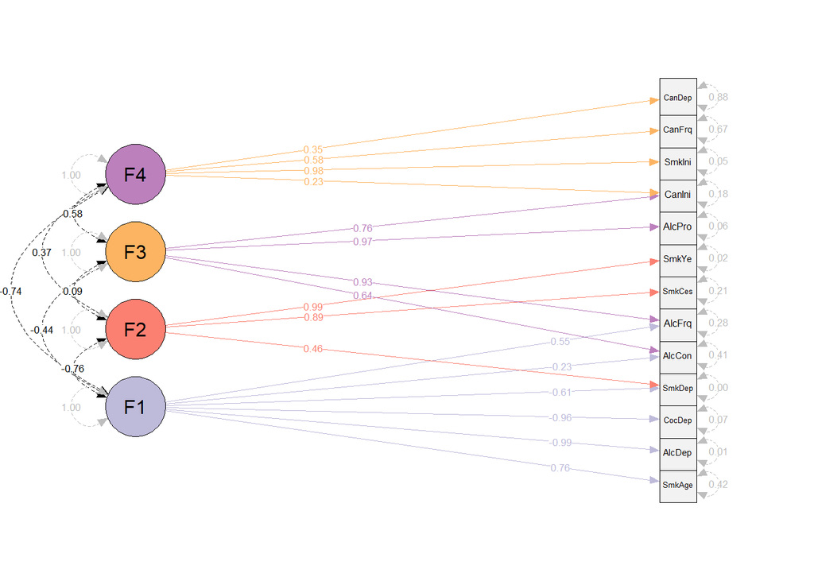

```r
semPaths(semPlotModel_GSEM(fit),
         layout="tree",
         curve = 2.5,
         whatLabels = "est",
         residuals = T,
         nodeLabels = nodelab,
         edge.color = edge.col,
         color = list(lat = c("#bebada", "#fb8072", "#fdb462", "#bc80bd"),
              man = "#f2f2f2"),
         rotation = 2
         ,edge.label.position = c(rep(0.8, 6), rep(0.3, 3), rep(0.4, 4), rep(0.3, 4), rep(0.5, 29))
         )
```

## EFA S-1 bifactor

```r
load("data/hdl_10January2024.14.RData")

bif <- 'G =~ NA*SMKCES + PACKYE + SMKDEP + CANDEP + COCDEP + SMKAGE + ALCDEP + CANEV + CANFL + SMKINI + ALCCON + ALCFRQ + ALCP

F2 =~ NA*CANDEP + COCDEP + SMKAGE
F3 =~ NA*ALCDEP + ALCCON + ALCFRQ + ALCP
F4 =~ NA*CANEV + CANFL + SMKINI

G~~1*G
F2~~1*F2
F3~~1*F3
F4~~1*F4

G ~~ 0*F2 + 0*F3 + 0*F4

a>.001
CANEV~~a*CANEV

b>.001
SMKDEP~~b*SMKDEP

c>.001
ALCDEP~~c*ALCDEP

d>.001
ALCP~~d*ALCP
'

#run the model
fit <- usermodel(hdlOut, estimation = "DWLS", model = bif, CFIcalc = TRUE)
```

```r
fitlabel <- paste0("CFI = ", round(fit$modelfit$CFI,3), ", SRMR = ", round(fit$modelfit$SRMR,3))
kable(fitlabel)
```

| x |
| --- |
| CFI = 0.966, SRMR = 0.082 |

**Click to expand table with model parameters**

```r
kable(fit$results)
```

|  | lhs | op | rhs | Unstand_Est | Unstand_SE | STD_Genotype | STD_Genotype_SE | STD_All | p_value |
| --- | --- | --- | --- | --- | --- | --- | --- | --- | --- |
| 39 | G | =~ | SMKCES | 0.1685454 | 0.00907412109950253 | 0.8044132 | 0.0433084827515136 | 0.8044132 | 0.0000000 |
| 37 | G | =~ | PACKYE | 0.2421513 | 0.00949268356662639 | 0.8707156 | 0.0341278919993043 | 0.8707155 | 0.0000000 |
| 40 | G | =~ | SMKDEP | 0.2344488 | 0.0167713837934556 | 1.0474607 | 0.0746507686103067 | 1.0474607 | 0.0000000 |
| 33 | G | =~ | CANDEP | 0.1317954 | 0.0217051708910403 | 0.2923684 | 0.0482132023012211 | 0.2923683 | 0.0000000 |
| 36 | G | =~ | COCDEP | 0.2912651 | 0.0239368911314977 | 0.8013054 | 0.0658583971323432 | 0.8013042 | 0.0000000 |
| 38 | G | =~ | SMKAGE | -0.1388657 | 0.00946734942756669 | -0.7810348 | 0.0532786863212219 | -0.7810349 | 0.0000000 |
| 30 | G | =~ | ALCDEP | 0.2426290 | 0.0165232118159848 | 0.8065651 | 0.0547736651435728 | 0.8021904 | 0.0000000 |
| 34 | G | =~ | CANEV | 0.0043891 | 0.0210920211664842 | 0.0118497 | 0.0615461302770986 | 0.0109740 | 0.8351548 |
| 35 | G | =~ | CANFL | 0.0019953 | 0.0119888317109737 | 0.0076917 | 0.0509512879216045 | 0.0076917 | 0.8678210 |
| 41 | G | =~ | SMKINI | 0.1725353 | 0.00915929983128103 | 0.5008537 | 0.026604142836838 | 0.5008538 | 0.0000000 |
| 29 | G | =~ | ALCCON | 0.0796790 | 0.00805001439310952 | 0.3003096 | 0.0303247020644375 | 0.3003096 | 0.0000000 |
| 31 | G | =~ | ALCFRQ | -0.1170048 | 0.00805614172304583 | -0.3870548 | 0.0266670879376059 | -0.3870547 | 0.0000000 |
| 32 | G | =~ | ALCP | 0.0329082 | 0.0104271066078873 | 0.1568257 | 0.0497709591086346 | 0.1546013 | 0.0015994 |
| 12 | F2 | =~ | CANDEP | 0.1122103 | 0.0377792884686683 | 0.2493943 | 0.0837109384739632 | 0.2493943 | 0.0029765 |
| 13 | F2 | =~ | COCDEP | 0.1770425 | 0.0647650863151735 | 0.4875172 | 0.177752631321522 | 0.4875165 | 0.0062644 |
| 14 | F2 | =~ | SMKAGE | -0.0408842 | 0.0142262970848077 | -0.2307942 | 0.080012438474232 | -0.2307942 | 0.0040551 |
| 18 | F3 | =~ | ALCDEP | 0.1804361 | 0.0168743194579336 | 0.5994903 | 0.0559262522601659 | 0.5962387 | 0.0000000 |
| 17 | F3 | =~ | ALCCON | 0.2072199 | 0.00813668980237023 | 0.7810158 | 0.0306441490722627 | 0.7810158 | 0.0000000 |
| 19 | F3 | =~ | ALCFRQ | 0.2053662 | 0.00964333368359068 | 0.6791092 | 0.0318382277132895 | 0.6791091 | 0.0000000 |
| 20 | F3 | =~ | ALCP | 0.2088702 | 0.00838912242104643 | 1.0016922 | 0.0400642324824888 | 0.9874848 | 0.0000000 |
| 22 | F4 | =~ | CANEV | 0.3690224 | 0.0213365138294138 | 1.0792618 | 0.0622872452747327 | 0.9995108 | 0.0000000 |
| 23 | F4 | =~ | CANFL | 0.1795276 | 0.0116618760285762 | 0.7638948 | 0.0496065714411689 | 0.7638935 | 0.0000000 |
| 24 | F4 | =~ | SMKINI | 0.2291121 | 0.00950738372309357 | 0.6664178 | 0.0276142690513581 | 0.6664179 | 0.0000000 |
| 6 | CANEV | ~~ | CANEV | 0.0010000 | 0.0150120822058485 | 0.0010000 | 0.128141952101667 | 0.0010000 | 0.9468898 |
| 45 | SMKDEP | ~~ | SMKDEP | 0.0010000 | 0.00770473208786398 | 0.0010000 | 0.152996580619174 | 0.0010000 | 0.8967327 |
| 2 | ALCDEP | ~~ | ALCDEP | 0.0010000 | 0.0103698339451079 | 0.0010008 | 0.11410371460693 | 0.0010008 | 0.9231761 |
| 4 | ALCP | ~~ | ALCP | 0.0010000 | 0.00440513121513869 | 0.0010004 | 0.100626850869284 | 0.0010004 | 0.8204252 |
| 46 | SMKINI | ~~ | SMKINI | 0.0359794 | 0.00512096887764378 | 0.3050326 | 0.0432557909260582 | 0.3050327 | 0.0000000 |
| 44 | SMKCES | ~~ | SMKCES | 0.0154909 | 0.00421759104657571 | 0.3529194 | 0.0960796544629498 | 0.3529194 | 0.0002398 |
| 42 | PACKYE | ~~ | PACKYE | 0.0187344 | 0.00459897144302055 | 0.2418545 | 0.0594154854545209 | 0.2418544 | 0.0000463 |
| 43 | SMKAGE | ~~ | SMKAGE | 0.0106164 | 0.00271231168179429 | 0.3367183 | 0.085941271113536 | 0.3367185 | 0.0000907 |
| 1 | ALCCON | ~~ | ALCCON | 0.0210643 | 0.00331066969617628 | 0.2998284 | 0.0470161693264642 | 0.2998285 | 0.0000000 |
| 3 | ALCFRQ | ~~ | ALCFRQ | 0.0352314 | 0.0043239044451929 | 0.3889996 | 0.0472224839951002 | 0.3889995 | 0.0000000 |
| 5 | CANDEP | ~~ | CANDEP | 0.1729855 | 0.0238248734811702 | 0.8523234 | 0.117385173427092 | 0.8523232 | 0.0000000 |
| 7 | CANFL | ~~ | CANFL | 0.0230854 | 0.00760162099782413 | 0.4164089 | 0.137445670716217 | 0.4164075 | 0.0023902 |
| 8 | COCDEP | ~~ | COCDEP | 0.0159087 | 0.0296976473118929 | 0.1202395 | 0.224648960824334 | 0.1202392 | 0.5921742 |
| 10 | F2 | ~~ | F3 | 0.4095462 | 0.16491017496784 | 0.4079231 | 0.163874961042023 | 0.4079231 | 0.0130117 |
| 11 | F2 | ~~ | F4 | 0.9979606 | 0.308825303056242 | 0.9985450 | 0.307920646783868 | 0.9985450 | 0.0012315 |
| 16 | F3 | ~~ | F4 | 0.6872907 | 0.0317714554845137 | 0.6865632 | 0.0316975918075939 | 0.6865632 | 0.0000000 |
| 28 | G | ~~ | G | 1.0000000 |  | 1.0000000 |  | 1.0000000 | NA |
| 9 | F2 | ~~ | F2 | 1.0000000 |  | 1.0000000 |  | 1.0000000 | NA |
| 15 | F3 | ~~ | F3 | 1.0000000 |  | 1.0000000 |  | 1.0000000 | NA |
| 21 | F4 | ~~ | F4 | 1.0000000 |  | 1.0000000 |  | 1.0000000 | NA |
| 25 | G | ~~ | F2 | 0.0000000 |  | 0.0000000 |  | 0.0000000 | NA |
| 26 | G | ~~ | F3 | 0.0000000 |  | 0.0000000 |  | 0.0000000 | NA |
| 27 | G | ~~ | F4 | 0.0000000 |  | 0.0000000 |  | 0.0000000 | NA |

## Theoretical bifactor - per substance model

```r
load("data/hdl_10January2024.14.RData")

bif <- 'G =~ NA*PACKYE + SMKCES + SMKDEP + SMKAGE + SMKINI + ALCCON + ALCFRQ + ALCP + ALCDEP + CANEV + CANFL + CANDEP + COCDEP

SMK =~ NA*PACKYE + SMKCES + SMKDEP + SMKAGE + SMKINI
ALC =~ NA*ALCCON + ALCFRQ + ALCP + ALCDEP
CAN =~ NA*CANEV + CANFL + CANDEP

G ~~ 0*SMK + 0*ALC + 0*CAN

G~~1*G
SMK~~1*SMK
ALC~~1*ALC
CAN~~1*CAN

a>.001
   ALCP~~a*ALCP

b>.001
  CANEV~~b*CANEV

c>-.99
  CAN~~c*SMK
'

#run the model
fit <- usermodel(hdlOut, estimation = "DWLS", model = bif, CFIcalc = TRUE)
```

```r
fitlabel <- paste0("CFI = ", round(fit$modelfit$CFI,3), ", SRMR = ", round(fit$modelfit$SRMR,3))
kable(fitlabel)
```

| x |
| --- |
| CFI = 0.965, SRMR = 0.061 |

**Click to expand table with model parameters**

```r
kable(fit$results)
```

|  | lhs | op | rhs | Unstand_Est | Unstand_SE | STD_Genotype | STD_Genotype_SE | STD_All | p_value |
| --- | --- | --- | --- | --- | --- | --- | --- | --- | --- |
| 31 | G | =~ | PACKYE | 0.2243239 | 0.0113945333508686 | 0.7928124 | 0.0388233709873164 | 0.7928123 | 0.0000000 |
| 33 | G | =~ | SMKCES | 0.1537877 | 0.0102849923014753 | 0.7254978 | 0.0478249543406626 | 0.7254977 | 0.0000000 |
| 34 | G | =~ | SMKDEP | 0.2248905 | 0.0161370555483184 | 1.0026783 | 0.0712933472533756 | 1.0026784 | 0.0000000 |
| 32 | G | =~ | SMKAGE | -0.1391901 | 0.00894775508887698 | -0.7863442 | 0.050575711865108 | -0.7863443 | 0.0000000 |
| 35 | G | =~ | SMKINI | 0.2500180 | 0.0101370443135437 | 0.7069635 | 0.0289928844280495 | 0.7069634 | 0.0000000 |
| 23 | G | =~ | ALCCON | 0.1289999 | 0.0100014596177058 | 0.5049029 | 0.0361713957161467 | 0.5049029 | 0.0000000 |
| 25 | G | =~ | ALCFRQ | -0.0491132 | 0.0112386532324408 | -0.1474482 | 0.0369491809632531 | -0.1474482 | 0.0000124 |
| 26 | G | =~ | ALCP | 0.0898807 | 0.0110895662111076 | 0.4525240 | 0.0514238470848852 | 0.4525239 | 0.0000000 |
| 24 | G | =~ | ALCDEP | 0.2780280 | 0.0159413224194723 | 0.9389714 | 0.0526079533676842 | 0.9389714 | 0.0000000 |
| 28 | G | =~ | CANEV | 0.1505560 | 0.0257427470715993 | 0.4861975 | 0.075547766885279 | 0.4705250 | 0.0000000 |
| 29 | G | =~ | CANFL | 0.0726529 | 0.0144537035344586 | 0.3352880 | 0.0623993325366831 | 0.3352874 | 0.0000005 |
| 27 | G | =~ | CANDEP | 0.1647938 | 0.0208407587860828 | 0.3708915 | 0.0462373985406529 | 0.3708915 | 0.0000000 |
| 30 | G | =~ | COCDEP | 0.3404901 | 0.0224241865533724 | 0.9464214 | 0.0623843162238724 | 0.9464214 | 0.0000000 |
| 40 | SMK | =~ | PACKYE | 0.1236150 | 0.0176161030426255 | -0.4120619 | 0.0611212611703303 | -0.4120619 | 0.0000000 |
| 42 | SMK | =~ | SMKCES | 0.0842201 | 0.0122923642150944 | -0.3784822 | 0.056061974821581 | -0.3784821 | 0.0000000 |
| 43 | SMK | =~ | SMKDEP | 0.0461150 | 0.0200243991374138 | -0.2092107 | 0.0808536038862958 | -0.2092107 | 0.0212822 |
| 41 | SMK | =~ | SMKAGE | -0.0284645 | 0.0118124370352034 | 0.1814813 | 0.0609921333840349 | 0.1814813 | 0.0159652 |
| 44 | SMK | =~ | SMKINI | -0.1542350 | 0.0253042108469879 | 0.3669366 | 0.0599103981191273 | 0.3669366 | 0.0000000 |
| 3 | ALC | =~ | ALCCON | 0.1627334 | 0.011409202501786 | 0.6008344 | 0.04287973329374 | 0.6008344 | 0.0000000 |
| 5 | ALC | =~ | ALCFRQ | 0.2510417 | 0.012657680377669 | 0.8382031 | 0.0416056803783477 | 0.8382031 | 0.0000000 |
| 6 | ALC | =~ | ALCP | 0.1826554 | 0.0110025734912465 | 0.8607762 | 0.0522796385051121 | 0.8607762 | 0.0000000 |
| 4 | ALC | =~ | ALCDEP | 0.0884792 | 0.0206312809130357 | 0.2733895 | 0.0675613998077713 | 0.2733895 | 0.0000180 |
| 13 | CAN | =~ | CANEV | 0.3285995 | 0.0386865426417077 | 0.9112292 | 0.118901573907253 | 0.8818558 | 0.0000000 |
| 14 | CAN | =~ | CANFL | 0.1577789 | 0.0182119970747186 | 0.6298828 | 0.080939254400764 | 0.6298818 | 0.0000000 |
| 12 | CAN | =~ | CANDEP | 0.0233133 | 0.0223893623690563 | 0.0408908 | 0.0466421338683981 | 0.0408908 | 0.2977525 |
| 10 | ALCP | ~~ | ALCP | 0.0024216 | 0.00440006464926571 | 0.0542865 | 0.100119949862122 | 0.0542865 | 0.5820801 |
| 16 | CANEV | ~~ | CANEV | 0.0009998 | 0.0223854785809198 | 0.0009999 | 0.189737731130623 | 0.0009999 | 0.9643743 |
| 38 | SMK | ~~ | CAN | -0.9900000 | 0.132517561188043 | 1.2763638 | 0.189540122697217 | 1.2763638 | 0.0000000 |
| 48 | SMKINI | ~~ | SMKINI | 0.0319427 | 0.0083212533259503 | 0.3655603 | 0.055393000311865 | 0.3655602 | 0.0001237 |
| 46 | SMKCES | ~~ | SMKCES | 0.0131547 | 0.00411390785386365 | 0.3304044 | 0.0939069972310689 | 0.3304043 | 0.0013857 |
| 36 | PACKYE | ~~ | PACKYE | 0.0117698 | 0.00535481732841439 | 0.2016537 | 0.0648469136992026 | 0.2016536 | 0.0279509 |
| 45 | SMKAGE | ~~ | SMKAGE | 0.0113875 | 0.00255351420491529 | 0.3487272 | 0.081205086491357 | 0.3487272 | 0.0000082 |
| 47 | SMKDEP | ~~ | SMKDEP | -0.0021669 | 0.00761790699096572 | -0.0491330 | 0.151588454752636 | -0.0491330 | 0.7760706 |
| 7 | ALCCON | ~~ | ALCCON | 0.0272300 | 0.0032172429488971 | 0.3840711 | 0.0460408357383696 | 0.3840711 | 0.0000000 |
| 9 | ALCFRQ | ~~ | ALCFRQ | 0.0256627 | 0.00577945604452085 | 0.2756746 | 0.0637711766290152 | 0.2756746 | 0.0000090 |
| 8 | ALCDEP | ~~ | ALCDEP | 0.0060331 | 0.00968976222467348 | 0.0435908 | 0.107808263487337 | 0.0435908 | 0.5335273 |
| 15 | CANDEP | ~~ | CANDEP | 0.1752462 | 0.0217792350938574 | 0.8607674 | 0.107376585311888 | 0.8607674 | 0.0000000 |
| 17 | CANFL | ~~ | CANFL | 0.0251469 | 0.00864498065536211 | 0.4908328 | 0.154282781981657 | 0.4908312 | 0.0036277 |
| 18 | COCDEP | ~~ | COCDEP | 0.0161545 | 0.0247298937514228 | 0.1042866 | 0.18832939108708 | 0.1042866 | 0.5136022 |
| 37 | SMK | ~~ | ALC | -0.5921600 | 0.0497227461850353 | 0.6822247 | 0.0641413291224475 | 0.6822247 | 0.0000000 |
| 2 | ALC | ~~ | CAN | 0.6991742 | 0.0742239577223868 | 0.7210130 | 0.0840224137013439 | 0.7210130 | 0.0000000 |
| 22 | G | ~~ | SMK | 0.0000000 |  | 0.0000000 |  | 0.0000000 | NA |
| 19 | G | ~~ | ALC | 0.0000000 |  | 0.0000000 |  | 0.0000000 | NA |
| 20 | G | ~~ | CAN | 0.0000000 |  | 0.0000000 |  | 0.0000000 | NA |
| 21 | G | ~~ | G | 1.0000000 |  | 1.0000000 |  | 1.0000000 | NA |
| 39 | SMK | ~~ | SMK | 1.0000000 |  | 1.0000000 |  | 1.0000000 | NA |
| 1 | ALC | ~~ | ALC | 1.0000000 |  | 1.0000000 |  | 1.0000000 | NA |
| 11 | CAN | ~~ | CAN | 1.0000000 |  | 1.0000000 |  | 1.0000000 | NA |

## Theoretical bifactor - per trait model

```r
load("data/hdl_10January2024.14.RData")

bif <- 'G =~ NA*SMKINI + SMKAGE + CANEV + PACKYE + ALCCON + ALCFRQ + ALCP + CANFL + SMKDEP + ALCDEP + CANDEP + COCDEP

INI =~ NA*SMKINI + SMKAGE + CANEV
FRQ =~ NA*PACKYE + ALCCON + ALCFRQ + ALCP + CANFL
DEP =~ NA*SMKDEP + ALCDEP + CANDEP + COCDEP

G ~~ 0*INI + 0*FRQ + 0*DEP

G~~1*G
INI~~1*INI
FRQ~~1*FRQ
DEP~~1*DEP

a > 0.001
SMKDEP~~a*SMKDEP

b>.001
ALCP~~b*ALCP

c>.001
ALCDEP~~c*ALCDEP

d>.001
CANEV~~d*CANEV
'

#run the model
fit <- usermodel(hdlOut, estimation = "DWLS", model = bif, CFIcalc = TRUE)
```

```r
fitlabel <- paste0("CFI = ", round(fit$modelfit$CFI,3), ", SRMR = ", round(fit$modelfit$SRMR,3))
kable(fitlabel)
```

| x |
| --- |
| CFI = 0.971, SRMR = 0.074 |

**Click to expand table with model parameters**

```r
kable(fit$results)
```

|  | lhs | op | rhs | Unstand_Est | Unstand_SE | STD_Genotype | STD_Genotype_SE | STD_All | p_value |
| --- | --- | --- | --- | --- | --- | --- | --- | --- | --- |
| 36 | G | =~ | SMKINI | 0.0072016 | 0.0384876814533475 | -0.0244074 | 0.111082598046718 | -0.0244074 | 0.8515710 |
| 34 | G | =~ | SMKAGE | -0.0990047 | 0.018365031849778 | 0.5603098 | 0.102324328197844 | 0.5603098 | 0.0000001 |
| 30 | G | =~ | CANEV | -0.1974472 | 0.0356915972436169 | 0.5780220 | 0.104417756455225 | 0.5652571 | 0.0000000 |
| 33 | G | =~ | PACKYE | 0.1712378 | 0.0221593674875049 | -0.6125276 | 0.0776610566161623 | -0.6125274 | 0.0000000 |
| 25 | G | =~ | ALCCON | -0.0835322 | 0.0291682352239414 | 0.3112812 | 0.109526865262973 | 0.3112812 | 0.0041858 |
| 27 | G | =~ | ALCFRQ | -0.2272841 | 0.0139349792161365 | 0.7488832 | 0.0461246934443771 | 0.7488833 | 0.0000000 |
| 28 | G | =~ | ALCP | -0.1228243 | 0.0277570627005744 | 0.5863957 | 0.132793820488497 | 0.5837457 | 0.0000096 |
| 31 | G | =~ | CANFL | -0.0729582 | 0.0220054217369993 | 0.3058362 | 0.0925157591745649 | 0.3058362 | 0.0009149 |
| 35 | G | =~ | SMKDEP | 0.1240772 | 0.0313643029598564 | -0.5727051 | 0.141872666382289 | -0.5724079 | 0.0000762 |
| 26 | G | =~ | ALCDEP | 0.0516282 | 0.0482314082338241 | -0.1758871 | 0.158451105430504 | -0.1758871 | 0.2844274 |
| 29 | G | =~ | CANDEP | 0.0635174 | 0.0289164986810245 | -0.1425856 | 0.0637144763949962 | -0.1425856 | 0.0280506 |
| 32 | G | =~ | COCDEP | 0.1559154 | 0.0539148700698645 | -0.4332227 | 0.146828851374722 | -0.4332226 | 0.0038294 |
| 42 | INI | =~ | SMKINI | 0.3032854 | 0.00919870350702677 | 0.8833451 | 0.0267379837025648 | 0.8833452 | 0.0000000 |
| 41 | INI | =~ | SMKAGE | -0.1295849 | 0.0168780739932343 | -0.7260647 | 0.0945710756818932 | -0.7260647 | 0.0000000 |
| 40 | INI | =~ | CANEV | 0.2854606 | 0.0305562902321077 | 0.8429505 | 0.0890669620923012 | 0.8243349 | 0.0000000 |
| 20 | FRQ | =~ | PACKYE | 0.1530669 | 0.0279621153980668 | -0.5412063 | 0.0990980716540431 | -0.5412062 | 0.0000000 |
| 16 | FRQ | =~ | ALCCON | 0.1944516 | 0.0144353279812767 | -0.7364895 | 0.0536328976128283 | -0.7364895 | 0.0000000 |
| 17 | FRQ | =~ | ALCFRQ | 0.0616050 | 0.0364618047180096 | -0.2075724 | 0.119194776934257 | -0.2075724 | 0.0911091 |
| 18 | FRQ | =~ | ALCP | 0.1689044 | 0.0207664138706449 | -0.8150090 | 0.0984964017415109 | -0.8113259 | 0.0000000 |
| 19 | FRQ | =~ | CANFL | 0.1351085 | 0.0153771033063241 | -0.5727478 | 0.0645230065069551 | -0.5727478 | 0.0000000 |
| 13 | DEP | =~ | SMKDEP | -0.1797091 | 0.0247949746230789 | 0.8197851 | 0.113141122258049 | 0.8193597 | 0.0000000 |
| 10 | DEP | =~ | ALCDEP | -0.2937678 | 0.0217752645364385 | 0.9751646 | 0.0723283419531559 | 0.9751646 | 0.0000000 |
| 11 | DEP | =~ | CANDEP | -0.1560301 | 0.0231310642432438 | 0.3462252 | 0.051330927396123 | 0.3462252 | 0.0000000 |
| 12 | DEP | =~ | COCDEP | -0.3268042 | 0.0388091841229086 | 0.8982627 | 0.106747623296857 | 0.8982626 | 0.0000000 |
| 45 | SMKDEP | ~~ | SMKDEP | 0.0010000 | 0.00838855109783593 | 0.0010000 | 0.174673306393017 | 0.0010000 | 0.9051085 |
| 4 | ALCP | ~~ | ALCP | 0.0010000 | 0.00444517975962315 | 0.0010003 | 0.102066204064225 | 0.0010003 | 0.8220125 |
| 2 | ALCDEP | ~~ | ALCDEP | 0.0019586 | 0.0132001787103808 | 0.0181178 | 0.145424801667456 | 0.0181178 | 0.8820469 |
| 6 | CANEV | ~~ | CANEV | 0.0010000 | 0.0132895929914301 | 0.0010001 | 0.115082271802681 | 0.0010001 | 0.9400182 |
| 46 | SMKINI | ~~ | SMKINI | 0.0258086 | 0.00507540103830645 | 0.2191056 | 0.0430593436814579 | 0.2191056 | 0.0000004 |
| 43 | PACKYE | ~~ | PACKYE | 0.0264288 | 0.00541985290970905 | 0.3319062 | 0.0685110574701634 | 0.3319060 | 0.0000011 |
| 44 | SMKAGE | ~~ | SMKAGE | 0.0050012 | 0.0026850806705892 | 0.1588830 | 0.0849433810127002 | 0.1588830 | 0.0625194 |
| 1 | ALCCON | ~~ | ALCCON | 0.0253122 | 0.00345827699613097 | 0.3606873 | 0.0493174579457798 | 0.3606872 | 0.0000000 |
| 3 | ALCFRQ | ~~ | ALCFRQ | 0.0359532 | 0.00488086570060448 | 0.3960875 | 0.0530586208389768 | 0.3960876 | 0.0000000 |
| 5 | CANDEP | ~~ | CANDEP | 0.1745700 | 0.0221256775721964 | 0.8597975 | 0.109022401012747 | 0.8597975 | 0.0000000 |
| 7 | CANFL | ~~ | CANFL | 0.0323901 | 0.00717693134647149 | 0.5784244 | 0.128238408410081 | 0.5784242 | 0.0000064 |
| 8 | COCDEP | ~~ | COCDEP | 0.0011032 | 0.0286639240354174 | 0.0054425 | 0.216842147000012 | 0.0054425 | 0.9692993 |
| 38 | INI | ~~ | FRQ | 0.7783414 | 0.0307158362121348 | -0.7769553 | 0.0306316746027925 | -0.7769553 | 0.0000000 |
| 37 | INI | ~~ | DEP | -0.8711455 | 0.0657728181394611 | 0.8692204 | 0.0656379880502498 | 0.8692204 | 0.0000000 |
| 14 | FRQ | ~~ | DEP | -0.9814634 | 0.080538751667463 | -0.9775947 | 0.0802528773251929 | -0.9775947 | 0.0000000 |
| 24 | G | ~~ | INI | 0.0000000 |  | 0.0000000 |  | 0.0000000 | NA |
| 22 | G | ~~ | FRQ | 0.0000000 |  | 0.0000000 |  | 0.0000000 | NA |
| 21 | G | ~~ | DEP | 0.0000000 |  | 0.0000000 |  | 0.0000000 | NA |
| 23 | G | ~~ | G | 1.0000000 |  | 1.0000000 |  | 1.0000000 | NA |
| 39 | INI | ~~ | INI | 1.0000000 |  | 1.0000000 |  | 1.0000000 | NA |
| 15 | FRQ | ~~ | FRQ | 1.0000000 |  | 1.0000000 |  | 1.0000000 | NA |
| 9 | DEP | ~~ | DEP | 1.0000000 |  | 1.0000000 |  | 1.0000000 | NA |